# Intro

### Structure

These sections were executed on a local machine.

1. Text Retrieval

2. Text Pre-Processing

3. Extracting 8-K Events

4. Negation Encoding

5. Normalization and Discretization

These sections were executed on Google Colab.

6. Exploratory Analysis

7. Baseline

8. CatBoost

9. LSTM with GloVe

10. Best Model Evaluation

### Environment

After `Normalization and Discretization`, the data is basically prepared for training models. Hence, I subsequently used the cloud computing environment Google Colab to speed things up and have access to more memory. Until `Normalization and Discretization`, it's best to use a local machine for downloading and reading the data.

### Initialization

```python
import numpy as np
import pandas as pd
import matplotlib.pyplot as plt
import seaborn as sns; sns.set(); sns.set_style("whitegrid")
from scipy.stats import describe

from IPython.core.display import display, HTML
from bs4 import BeautifulSoup
from io import StringIO
import requests
import re

from tqdm import tqdm
import zipfile
import pickle
import time
import sys
import os
import gc

# Sklearn
from sklearn.pipeline import Pipeline
from sklearn.feature_extraction.text import CountVectorizer
from sklearn.feature_extraction.text import TfidfVectorizer
from sklearn.metrics import confusion_matrix, classification_report, accuracy_score, f1_score
from sklearn.model_selection import train_test_split
from sklearn.model_selection import GridSearchCV

from sklearn.naive_bayes import MultinomialNB
from sklearn.linear_model import LogisticRegression
from sklearn.linear_model import SGDClassifier
from sklearn.ensemble import RandomForestClassifier

# Check python version
from platform import python_version
print(python_version())
```

```
3.6.9
```

```python
# Define function for evaluation
def evaluate(y_te, pred, labels, return_data = False):

    cm = confusion_matrix(y_te, pred, labels)

    print("\nConfusion matrix (absolute):")
    cm_abs = pd.DataFrame(data = cm, index = labels, columns = labels)
    cm_abs = pd.concat([cm_abs], keys=['True'], names=[''], axis = 0)
    cm_abs = pd.concat([cm_abs], keys=['Predicted'], names=[''], axis = 1)
    display(cm_abs)

    print("\nConfusion matrix (relative):")
    cm_rel = pd.DataFrame(data = cm / cm.sum(), index = labels, columns = labels)
    cm_rel = pd.concat([cm_rel], keys=['True'], names=[''], axis = 0)
    cm_rel = pd.concat([cm_rel], keys=['Predicted'], names=[''], axis = 1)
    cm_rel = round(cm_rel * 100, 2)
    display(cm_rel)

    print("\nClassification report:\n")
    class_report = classification_report(y_true = y_te, y_pred = pred)
    print(class_report)

    acc = round(accuracy_score(y_true = y_te, y_pred = pred), 4)
    print("Overall accuracy: {}".format(acc))
    f1 = round(f1_score(y_true = y_te, y_pred = pred, average='weighted'), 4)
    print("Overall f1_score: {}".format(f1))

    if return_data == True:
        return({'cm_rel': cm_rel, 'cm_abs': cm_abs, 'class_report': class_report, 'acc': acc, 'f1': f1})
```

```python
# ONLY FOR COLAB
base_path = '/content/gdrive/My Drive/textmining-report/main'
from google.colab import drive
drive.mount('/content/gdrive')
```

```
Go to this URL in a browser: https://accounts.google.com/o/oauth2/auth?client_id=947318989803-6bn6qk8qdgf4n4g3pfee6491hc0brc4i.apps.googleusercontent.com&redirect_uri=urn%3aietf%3awg%3aoauth%3a2.0%3aoob&response_type=code&scope=email%20https%3a%2f%2fwww.googleapis.com%2fauth%2fdocs.test%20https%3a%2…

Enter your authorization code:
··········
```

```python
# ONLY FOR COLAB
!pip install catboost
```

```
     |████████████████████████████████| 63.9MB 47kB/s
```

```python
from catboost import CatBoostClassifier, Pool
import catboost
catboost.__version__
```

```
'0.20.2'
```

```python
# # Only for local PC
# base_path = "/mnt/c/Users/julius/Desktop/ALL/textmining-sec-8k"
# base_path = "/Users/julius/Desktop/ALL/textmining-sec-8k"
```

```python
!nvidia-smi
!nvcc --version
!lscpu |grep 'Model name'
!lscpu | grep 'Thread(s) per core'
!lscpu | grep "L3 cache"
!cat /proc/meminfo | grep 'MemAvailable'
!df -h / | awk '{print $4}'
```

```
Sun Dec 22 23:09:40 2019
+-----------------------------------------------------------------------------+
| NVIDIA-SMI 440.44       Driver Version: 418.67       CUDA Version: 10.1     |
|-------------------------------+----------------------+----------------------+
| GPU  Name        Persistence-M| Bus-Id        Disp.A | Volatile Uncorr. ECC |
| Fan  Temp  Perf  Pwr:Usage/Cap|         Memory-Usage | GPU-Util  Compute M. |
|===============================+======================+======================|
|   0  Tesla P100-PCIE...  Off  | 00000000:00:04.0 Off |                    0 |
| N/A   42C    P0    28W / 250W |      0MiB / 16280MiB |      0%      Default |
+-------------------------------+----------------------+----------------------+

+-----------------------------------------------------------------------------+
| Processes:                                                       GPU Memory |
|  GPU       PID   Type   Process name                             Usage      |
|=============================================================================|
|  No running processes found                                                 |
+-----------------------------------------------------------------------------+
nvcc: NVIDIA (R) Cuda compiler driver
Copyright (c) 2005-2018 NVIDIA Corporation
Built on Sat_Aug_25_21:08:01_CDT_2018
Cuda compilation tools, release 10.0, V10.0.130
Model name:          Intel(R) Xeon(R) CPU @ 2.20GHz
Thread(s) per core:  2
L3 cache:            56320K
MemAvailable:   25689040 kB
Avail
34G
```

# 1. Text Retrieval

A data set with the target variables is imported. Every row represents one 8-K filing. The data is already prepared by me, so that it can be merged with the corresponding 8-K filings later on. For this purpose, every row also contains the `CIK`, the `Ticker`, the `Date Filed` and the `Filename`. There are two target variables, `Y_cont` and `Y_disc`, but we will focus on these later.

To get the text data, you need to do make one request for each 8-K file. I recommend to get the raw data first and to do the data cleaning later. That way, you will always have access to the raw data and you can easily experiment with different data cleaning methods without having to repeat any requests.

```python
# Import target data
df_target = pd.read_csv("input/raw/target.csv")
df_target.loc[:, "Date Filed"] = pd.to_datetime(df_target.loc[:, "Date Filed"])
print("Dimensions: {}".format(df_target.shape))
display(df_target.head())
```

```
Dimensions: (42087, 61)
```

|  | CIK | Ticker | Date Filed | Company Name | Form Type | Filename | Name | Exchange | SIC | Business | ... | after_adjClose | after_adjHigh | after_adjLow | after_adjOpen | after_adjVolume | after_divCash | after_splitFactor | domain | Y_cont | Y_disc |
| --- | --- | --- | --- | --- | --- | --- | --- | --- | --- | --- | --- | --- | --- | --- | --- | --- | --- | --- | --- | --- | --- |
| 0 | 1000045 | NICK | 2019-02-01 | NICHOLAS FINANCIAL INC | 8-K | edgar/data/1000045/0001193125-19-024617.txt | Nicholas Financial Inc | NASDAQ | 6153.0 | FL | ... | 10.700000 | 10.726800 | 10.650000 | 10.672500 | 4865.0 | 0.0 | 1.0 | Finance, Insurance, Real Estate | 0.0162 | pos |
| 1 | 1000228 | HSIC | 2019-01-23 | HENRY SCHEIN INC | 8-K | edgar/data/1000228/0001193125-19-014864.txt | Henry Schein Inc | NASDAQ | 5047.0 | NY | ... | 60.078431 | 60.917647 | 59.682353 | 60.478431 | 1494994.0 | 0.0 | 1.0 | Wholesale Trade | -0.0048 | neg |
| 2 | 1000228 | HSIC | 2019-02-20 | HENRY SCHEIN INC | 8-K | edgar/data/1000228/0001000228-19-000012.txt | Henry Schein Inc | NASDAQ | 5047.0 | NY | ... | 59.980000 | 61.860000 | 59.506200 | 60.030000 | 3789625.0 | 0.0 | 1.0 | Wholesale Trade | -0.0488 | neg |
| 3 | 1000229 | CLB | 2019-01-15 | CORE LABORATORIES N V | 8-K | edgar/data/1000229/0001000229-19-000011.txt | Core Laboratories N V | NYSE | 1389.0 | P7 | ... | 68.203271 | 69.155360 | 67.419781 | 67.776815 | 242811.0 | 0.0 | 1.0 | Mining | -0.0025 | neg |
| 4 | 1000229 | CLB | 2019-01-30 | CORE LABORATORIES N V | 8-K | edgar/data/1000229/0001000229-19-000018.txt | Core Laboratories N V | NYSE | 1389.0 | P7 | ... | 67.460000 | 71.020000 | 65.150000 | 68.850000 | 1188703.0 | 0.0 | 1.0 | Mining | 0.0252 | pos |

5 rows × 61 columns

```python
# Create a path for storing the filings
path = "input/raw/filings"
if not os.path.exists(path):
    os.makedirs(path)

# Download all SEC filings (this will take some time)
N = len(df_target)
df_target["Filename Local"] = df_target["Filename"].str.replace("/", "_") + ".html"

for i, row in df_target.iterrows():

    # Make request
    url_file = "https://www.sec.gov/Archives/{}".format(row["Filename"])
    response = requests.get(url_file)

    # Write file
    with open("{}/{}".format(path, row["Filename Local"]),"w") as f:
        f.write(response.text)

    # Print status (comment this in, if you want status updates)
    #print("{} / {} | {} | {} | {} | {}".format(i, N=1, url_file, row["Company Name"],
    #                                           row["Ticker"], row["Date Filed"]))
```

```python
# Check that all files were downloaded
filenames = os.listdir("input/raw/filings")
df_sub = df_target[~df_target["Filename Local"].isin(filenames)]
if df_sub.empty:
    print("All files downloaded.")
```

```
All files downloaded.
```

# 2. Text Pre-Processing

We now have the downloaded 8-K filings and one CSV file with the target variables for each filing. We have to process the raw texts of the filings to make them usable for modelling. The goal is to get one CSV file containing both, the target values and the processed text, for all 8-K filings. The data is imported again (since this part of the notebook is probably run at a later time point, after the time consuming download from section 1).

```python
# Checking that there is one 8-K filing per row
filenames = os.listdir("input/raw/filings")
df_target = pd.read_csv("input/raw/target.csv")
df_target["Filename Local"] = df_target["Filename"].str.replace("/", "_") + ".html"
df_target_sub = df_target[df_target["Filename Local"].isin(filenames)]

print("Number of rows: {}".format(len(df_target)))
print("One 8-K filing per row: {}".format(df_target.shape[0] == df_target_sub.shape[0]))
```

```
Number of rows: 42087
One 8-K filing per row: True
```

## 2.1 Example

For this section, we make use of the amazing library `spaCy`. If you haven't already, you might have to install it following the descriptions on the official website: https://spacy.io/usage If you encounter issues, check your spacy version and your python version to ensure they work well together.

The documents contain some cases where there is a PDF inserted in the bottom of the 8-K filing. This part is removed with the code below `Handle special cases`, as we are only interested in text data before the PDF. Essentially, the data is then processed as follows:

1. Read the downloaded 8-K file as text file
2. Handle special cases (remove PDF from text)
3. Remove HTML tags
4. Get raw text (without tabs, spaces, newlines etc.)
5. Tokenize with spaces (alternatively with SpaCy)
6. Take lower-case lemmatized non-stop words with only alphabetical characters and length > 1
7. Create one string with space-separated lemmas

Note that the result of step 4 is saved separately as "raw" text later on in the data frame. Steps 5-7 are independent from step 4, i.e. they also build on step 3, and their result is saved as "text" later on in the data frame.

Before we do the processing for all 8-K filings, let's illustrate it with only 1 filing. Feel free to print out the results after each step yourself. I did not define a function for this to make it easier for you to play around with it.

Ideally, we would like to apply the below processing for all documents. However, this is not possible because the `text` in `tokens = nlp(text)` cannot have more than 1 Mio. characters. There are some very large documents with more characters .Therefore, we later need to approach these large documents differently. For now, we just mark them as "large".

```python
import spacy
nlp = spacy.load("en_core_web_sm", disable = ["tagger", "parser", "ner"])
vocab = set(nlp.vocab.strings)
```

```python
# Read the downloaded 8-K file as text file
filename = df_target.loc[0, "Filename Local"]
with open("input/raw/filings/{}".format(filename), "r") as f:
    text = f.read()
    #display(HTML(text))

# Handle special cases (remove PDF from text)
s = re.search(">GRAPHIC", text)
if s != None and s.span()[0] > 500:
    text = text.split(">GRAPHIC")[0]
text = text.split("PDF OF ENTIRE FORM 8-K")[0].split("<DESCRIPTION>PRINTABLE 8-K ")[0]

# Remove HTML tags
soup = BeautifulSoup(text, "html.parser")
text = soup.get_text(separator = " ")

# Get raw text (without tabs, spaces, newlines etc.)
raw = " ".join(text.split())

# Tokenize with SpaCy
tokens = nlp(text)

# Take lower-case lemmatized non-stop words with only alphabetical characters and length > 1
lemmas = [token.lemma_.lower() for token in tokens
          if not token.is_stop if token.is_alpha if len(token) > 1]

# Create one string with space-separated lemmas
text = " ".join(lemmas)

# Print result
print(text[0:1000], "\n")
print(raw[0:3000])
```

```
accession number conformed submission type public document count conformed period report item information results operations financial condition item information financial statements exhibits filed date date change filer company data company conformed nicholas financial inc central index key standar…

0001193125-19-024617.txt : 20190201 0001193125-19-024617.hdr.sgml : 20190201 20190201063107 ACCESSION NUMBER: 0001193125-19-024617 CONFORMED SUBMISSION TYPE: 8-K PUBLIC DOCUMENT COUNT: 3 CONFORMED PERIOD OF REPORT: 20190201 ITEM INFORMATION: Results of Operations and Financial Condition ITEM INFORMA…
```

## 2.2 Process all 8-K filings

Now, we process all documents as described in the example above to get one CSV file containing both, the target values and the processed text, for all 8-K filings. Also the raw text is included (only with removal of new lines, tabs etc.).

Note that the total filesize for all the raw 8-K filings is approx 50GB. After processing, the size will be smaller. Still, we might get memory issues. Therefore, we split the processing into 5 batches of approx. 10GB each. Furthermore, there are some 8-K filings that have too many characters. `SpaCy` can only handle a maximum of 1M characters when performing tokenization. When we encounter these large 8-K filings, we just mark them as "large" so that we can exclude them later on.

```python
byte = sum([os.path.getsize("input/raw/filings/{}".format(f))
            for f in os.listdir('input/raw/filings')
            if os.path.isfile("input/raw/filings/{}".format(f))])

print("Total size of all raw 8-K filings: {} GB".format(round(byte*(1e-9), 2)))
```

```
Total size of all raw 8-K filings: 49.59 GB
```

```python
print("Rows of full data frame: {}".format(df_target.shape[0]))
batches = np.array_split(df_target, 5)
total = 0

for df_batch in batches:
    total += df_batch.shape[0]
    print(df_batch.shape)

print("Rows of all batched data frames: {}".format(total))
```

```
Rows of full data frame: 42087
(8418, 62)
(8418, 62)
(8417, 62)
(8417, 62)
(8417, 62)
Rows of all batched data frames: 42087
```

```python
# Create directory for adjusted files
path = "input/adj"
if not os.path.exists(path):
    os.makedirs(path)

# Special escape elements to be removed
pattern = re.compile(u"(\ud83d[\ude00-\ude4f])|"  # emoticons
                   u"(\ud83c[\udf00-\uffff])|"  # symbols & pictographs (1 of 2)
                   u"(\ud83d[\u0000-\uddff])|"  # symbols & pictographs (2 of 2)
                   u"(\ud83d[\ude80-\udeff])|"  # transport & map symbols
                   u"(\ud83c[\udde0-\uddff])"  # flags (iOS)
                   "+", flags=re.UNICODE)

# Process each batch one at a time
for b, df_batch in zip(range(len(batches)), batches):

    N = df_batch.shape[0]
    df_batch["large"] = False
    cnt = 0

    for i, row in df_batch.iterrows():

        filename = df_batch.loc[i, "Filename Local"]

        # Read the downloaded 8-K file as text file
        with open("input/raw/filings/{}".format(filename), "r") as f:
            text = f.read()

        try:

            # Handle special cases (remove PDF from text)
            s = re.search(">GRAPHIC", text)
            if s != None and s.span()[0] > 500:
                text = text.split(">GRAPHIC")[0]
            text = text.split("PDF OF ENTIRE FORM 8-K")[0].split("<DESCRIPTION>PRINTABLE 8-K ")[0]

            # Remove HTML tags
            soup = BeautifulSoup(text, "html.parser")
            text = soup.get_text(separator = " ")

            # Remove special escape elements
            text = pattern.sub(r' ', text)

            # Pre-process text of non-large files
            if len(text) <= 1e6:

                # Get raw text (without tabs, spaces, newlines etc.)
                df_batch.loc[i, "raw"] = " ".join(text.split())

                # Tokenize with SpaCy
                tokens = nlp(text)

                # Take lower-case lemmatized non-stop words with only alphabetical characters and length > 1
                lemmas = [token.lemma_.lower() for token in tokens
                          if not token.is_stop if token.is_alpha if len(token) > 1]

                # Create one string with space-separated lemmas
                text = " ".join(lemmas)

                # Save the result
                df_batch.loc[i, "text"] = text

            else:
                df_batch.loc[i, "large"] = True

        except:

            df_batch.loc[i, "error"] = True
            print("\n ERROR:")

        # Print status (comment this in, if you want status updates)
        cnt += 1
#         print("{} | {} | {} / {} | {} | {} | {} | {}".format(b, i, cnt, N-1, filename, row["Company Name"],
#                                                             row["Ticker"], row["Date Filed"]))

    # Export data
    df_batch.to_csv("{}/target_withalltext_batch{}.csv".format(path, b), index = False)
```

It seems like the size of the processed files is small enough to concatenate them into one file.

```python
# Check size of processed files
byte = sum([os.path.getsize("input/adj/{}".format(f))
            for f in os.listdir('input/adj')
            if os.path.isfile("input/adj/{}".format(f))])

print("Total size of files with processed 8-K filings: {} GB".format(round(byte*(1e-9), 2)))
```

```
Total size of files with processed 8-K filings: 8.43 GB
```

```python
# Concatenate all files into one
frames = [pd.read_csv("input/adj/target_withalltext_batch0.csv"),
          pd.read_csv("input/adj/target_withalltext_batch1.csv"),
          pd.read_csv("input/adj/target_withalltext_batch2.csv"),
          pd.read_csv("input/adj/target_withalltext_batch3.csv"),
          pd.read_csv("input/adj/target_withalltext_batch4.csv")]
df_target = pd.concat(frames, axis = 0, sort = False)
print(df_target.shape) # 3 columns more: text, large, error
```

```
(42087, 66)
```

```python
# Check the number of files to be excluded (later)
print("Number of 8-K filings excluded because of errors in processing: {}".format(len(df_target[df_target["error"] == True])))
print("Number of 8-K filings excluded because of large file size: {}".format(len(df_target[df_target["large"] == True])))
```

```
Number of 8-K filings excluded because of errors in processing: 14
Number of 8-K filings excluded because of large file size: 308
```

```python
# Export result
df_target.to_csv("input/adj/target_withalltext.csv", index = False)
```

# 3. Extracting 8-K Events

Later, it might be good to know, which 8-K events each filing actually contains (https://www.sec.gov/fast-answers/answersform8khtm.html). Therefore, let's extract this information from the text data. Note that I added this section later. Hence, it's separate from section 2.2. You could also integrate this task into 2.2.

```python
# Import data with processed texts
df_target = pd.read_csv("input/adj/target_withalltext.csv")
print(df_target.shape)
df_target.head()
```

```
(42087, 66)
```

|  | CIK | Ticker | Date Filed | Company Name | Form Type | Filename | Name | Exchange | SIC | Business | ... | after_divCash | after_splitFactor | domain | Y_cont | Y_disc | Filename Local | large | raw | text | error |
| --- | --- | --- | --- | --- | --- | --- | --- | --- | --- | --- | --- | --- | --- | --- | --- | --- | --- | --- | --- | --- | --- |
| 0 | 1000045 | NICK | 2019-02-01 | NICHOLAS FINANCIAL INC | 8-K | edgar/data/1000045/0001193125-19-024617.txt | Nicholas Financial Inc | NASDAQ | 6153.0 | FL | ... | 0.0 | 1.0 | Finance, Insurance, Real Estate | 0.0162 | pos | edgar_data_1000045_0001193125-19-024617.txt.html | False | 0001193125-19-024617.txt : 20190201 0001193125... | accession number conformed submission type pub... | NaN |
| 1 | 1000228 | HSIC | 2019-01-23 | HENRY SCHEIN INC | 8-K | edgar/data/1000228/0001193125-19-014864.txt | Henry Schein Inc | NASDAQ | 5047.0 | NY | ... | 0.0 | 1.0 | Wholesale Trade | -0.0048 | neg | edgar_data_1000228_0001193125-19-014864.txt.html | False | 0001193125-19-014864.txt : 20190123 0001193125... | accession number conformed submission type pub... | NaN |
| 2 | 1000228 | HSIC | 2019-02-20 | HENRY SCHEIN INC | 8-K | edgar/data/1000228/0001000228-19-000012.txt | Henry Schein Inc | NASDAQ | 5047.0 | NY | ... | 0.0 | 1.0 | Wholesale Trade | -0.0488 | neg | edgar_data_1000228_0001000228-19-000012.txt.html | False | 0001000228-19-000012.txt : 20190220 0001000228... | accession number conformed submission type pub... | NaN |
| 3 | 1000229 | CLB | 2019-01-15 | CORE LABORATORIES N V | 8-K | edgar/data/1000229/0001000229-19-000011.txt | Core Laboratories N V | NYSE | 1389.0 | P7 | ... | 0.0 | 1.0 | Mining | -0.0025 | neg | edgar_data_1000229_0001000229-19-000011.txt.html | False | 0001000229-19-000011.txt : 20190115 0001000229... | accession number conformed submission type pub... | NaN |
| 4 | 1000229 | CLB | 2019-01-30 | CORE LABORATORIES N V | 8-K | edgar/data/1000229/0001000229-19-000018.txt | Core Laboratories N V | NYSE | 1389.0 | P7 | ... | 0.0 | 1.0 | Mining | 0.0252 | pos | edgar_data_1000229_0001000229-19-000018.txt.html | False | 0001000229-19-000018.txt : 20190130 0001000229... | accession number conformed submission type pub... | NaN |

5 rows × 66 columns

```python
# Import data with 8K categories
df_8k = pd.read_csv("input/raw/events_8k.csv")
df_8k.head()
```

|  | Item | Event | Section | Section_Name |
| --- | --- | --- | --- | --- |
| 0 | 1.01 | Entry into a Material Definitive Agreement | 1 | Registrant's Business and Operations |
| 1 | 1.02 | Termination of a Material Definitive Agreement | 1 | Registrant's Business and Operations |
| 2 | 1.03 | Bankruptcy or Receivership | 1 | Registrant's Business and Operations |
| 3 | 1.04 | Mine Safety - Reporting of Shutdowns and Patte... | 1 | Registrant's Business and Operations |
| 4 | 2.01 | Completion of Acquisition or Disposition of As... | 2 | Financial Information |

```python
# Process all raw filings
N = df_target.shape[0]

for i in range(N):

    if df_target.loc[i, "text"] != None:

        # Read the downloaded 8-K file as text file
        filename = df_target.loc[i, "Filename Local"]
        with open("input/raw/filings/{}".format(filename), "r") as f:
            text = f.read()

        try:

            # Handle special cases (remove PDF from text)
            s = re.search(">GRAPHIC", text)
            if s != None and s.span()[0] > 500:
                text = text.split(">GRAPHIC")[0]
            text = text.split("PDF OF ENTIRE FORM 8-K")[0].split("<DESCRIPTION>PRINTABLE 8-K ")[0]

            # Remove HTML tags
            soup = BeautifulSoup(text, "html.parser")
            text = soup.get_text(separator = " ")

            # Remove tabs, new lines and multiple spaces
            text = re.sub('\\xa0', ' ', text)
            text = re.sub('\xa0', ' ', text)
            text = re.sub('\t', ' ', text)
            text = re.sub('\n', ' ', text)
            text = re.sub(' +', ' ', text)

            # Check all categories
            item_list = []
            for j, row in df_8k.iterrows():
                item = "Item {}".format(row["Item"])
                event = row["Event"]
                if len(re.findall(item, text, flags = re.IGNORECASE)) > 0 or len(re.findall(event, text, flags = re.IGNORECASE)) > 0:
                    df_target.loc[i, item] = True
                    item_list.append(item)

            # Print status
            print("{} / {} | {} | {}".format(i, N-1, filename, " ".join(item_list)))


        except:

            # Print status
            #print("\n ERROR: NO ITEM IDENTIFIED: {} / {} | {}\n".format(i, N-1, filename))
            #df_target.loc[i, "no_item"] = True
```

For 14 filings, the item could not be extracted. These are all cases, for which we also could not extract the text for some reason. Hence, we don't need to worry about them since they will be removed before training models.

```python
print("# cases without item: {}".format(df_target.loc[df_target["no_item"] == True, :].shape[0]))
print("# cases without item and without text: {}".format(df_target.loc[(df_target["no_item"] == True) &
                                                                       (df_target["text"].isna()), :].shape[0]))
```

```
# cases without item: 14
# cases without item and without text: 14
```

```python
# Sort item columns
nonitem_cols = [column for column in df_target.columns.tolist() if column[0:4] != "Item"]
item_cols = [column for column in df_target.columns.tolist() if column[0:4] == "Item"]
df_target = df_target.loc[:, nonitem_cols + sorted(item_cols)]

# Replace NaN in item columns and other columns with False
df_target.loc[:, item_cols] = df_target.loc[:, item_cols].fillna(value = False)
df_target.loc[:, ["error", "no_item", "large"]] = df_target.loc[:, ["error", "no_item", "large"]].fillna(value = False)
```

```python
# Export data
df_target.to_csv("input/adj/target_withalltext_withevents.csv", index = False)
```

## 4. Negation Encoding

```python
import spacy
nlp = spacy.load("en_core_web_sm", disable = ["tagger", "parser", "ner"])
vocab = set(nlp.vocab.strings)
```

```python
# Import data
df = pd.read_csv("input/adj/target_withalltext_withevents.csv")
```

```python
# Encode Negation
for i, row in tqdm(df.iterrows()):

    # Take raw text
    text = row["raw"]

    # Negate words
    text = re.sub(r"\b(?:not|'t|never|no|neither|nor|nobody|noone|nothing|nowhere|cannot)\b[\w\s]+[^\w\s]",
                   lambda match: re.sub(r'(\s+)(\w+)', r'\1NEG_\2', match.group(0)), text, flags=re.IGNORECASE)

    # Other pre-processing
    try:

        if len(text) <= 1e6:

            # Tokenize with SpaCy
            tokens = nlp(text)

            # Take lower-case lemmatized non-stop words with only alphabetical characters and length > 1
            lemmas = []
            for token in tokens:
                if token.text[0:4] == "NEG_":
                    neg_token = nlp(token.text[4:])[0]
                    if (not neg_token.is_stop and neg_token.is_alpha and len(neg_token) > 1):
                        lemmas.append(token.lemma_.lower())
                else:
                    if (not token.is_stop and token.is_alpha and len(token) > 1):
                        lemmas.append(token.lemma_.lower())

            # Create one string with space-separated lemmas
            text = " ".join(lemmas)

            # Save the result
            df.loc[i, "text_neg"] = text

        else:
            df.loc[i, "large"] = True

    except:
        df.loc[i, "error"] = True
```

```python
# Export
df.to_csv("input/adj/target_withalltext_withevents.csv", index = False)
```

# 5. Normalization and Discretization

The data set with the target variables is imported. Every row represents one 8-K filing. `Y_cont` contains the percentage change from the `close` price on the day before the `Date Filed` to the `open` price on the day after the `Date Filed`.

```python
# Import target data
df_target = pd.read_csv("input/adj/target_withalltext_withevents.csv")
df_target.loc[:, "Date Filed"] = pd.to_datetime(df_target.loc[:, "Date Filed"])
print(df_target.shape)
display(df_target.head())
```

```
(42087, 94)
```

|  | CIK | Ticker | Date Filed | Company Name | Form Type | Filename | Name | Exchange | SIC | Business | ... | Item 3.02 | Item 5.08 | Item 5.07 | Item 7.01 | Item 3.03 | Item 2.02 | Item 2.06 | Item 5.01 | Item 5.04 | Item 2.05 |
| --- | --- | --- | --- | --- | --- | --- | --- | --- | --- | --- | --- | --- | --- | --- | --- | --- | --- | --- | --- | --- | --- |
| 0 | 1000045 | NICK | 2019-02-01 | NICHOLAS FINANCIAL INC | 8-K | edgar/data/1000045/0001193125-19-024617.txt | Nicholas Financial Inc | NASDAQ | 6153.0 | FL | ... | False | False | False | False | False | True | False | False | False | False |
| 1 | 1000228 | HSIC | 2019-01-23 | HENRY SCHEIN INC | 8-K | edgar/data/1000228/0001193125-19-014864.txt | Henry Schein Inc | NASDAQ | 5047.0 | NY | ... | False | False | False | True | False | False | False | False | False | False |
| 2 | 1000228 | HSIC | 2019-02-20 | HENRY SCHEIN INC | 8-K | edgar/data/1000228/0001000228-19-000012.txt | Henry Schein Inc | NASDAQ | 5047.0 | NY | ... | False | False | False | False | False | True | False | False | False | False |
| 3 | 1000229 | CLB | 2019-01-15 | CORE LABORATORIES N V | 8-K | edgar/data/1000229/0001000229-19-000011.txt | Core Laboratories N V | NYSE | 1389.0 | P7 | ... | False | False | False | True | False | False | False | False | False | False |
| 4 | 1000229 | CLB | 2019-01-30 | CORE LABORATORIES N V | 8-K | edgar/data/1000229/0001000229-19-000018.txt | Core Laboratories N V | NYSE | 1389.0 | P7 | ... | False | False | False | False | False | True | False | False | False | False |

5 rows × 94 columns

## 5.1 Normalization

Before we can actually use the data, we need to normalize it using the S&P 500, a stock price index with the 500 largest publicly traded companies in the US. The reason for this is that we want to only classify the stock price changes that happened because of the 8-K filings (and not because of the overall market trend). Therefore, we have to remove the effect of the overall market.

For instance if the stock price of a companie increased by 5 percent and if the S&P 500 increased by 2 percent in the same period, then the normalized percentage change will be 3 percent. Without this normalization, our model might e.g. perform noticeably better when classifying percentage increases during time periods where the S&P 500 was increasing. However, this might not generalize for time periods where the S&P 500 is decreasing.

The data of the S&P 500 is taken from yahoo finance (https://finance.yahoo.com/quote/%5EGSPC/history).

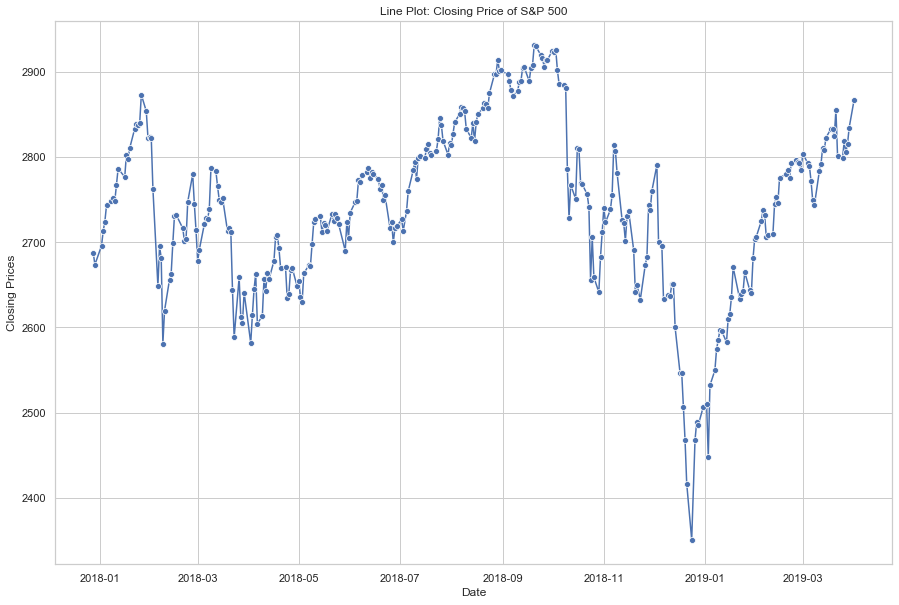

```python
# Import S&P 500 data
df_sp = pd.read_csv("input/raw/^GSPC.csv")
df_sp.loc[:, "Date"] = pd.to_datetime(df_sp.loc[:, "Date"])

%matplotlib inline
plt.rcParams["figure.figsize"] = [15,10]
p = sns.lineplot(x = "Date", y = "Close", data = df_sp, marker = "o", estimator = None)
p.set(ylabel = "Closing Prices", title = "Line Plot: Closing Price of S&P 500")
plt.show(p);
```

The target variable `Y_cont`, was computed as the percentage change from the closing price of the day before the 8-K filing to the opening price of the day after the 8-K filing. Therefore, we compute the equivalent percentage change of the S&P 500 for each 8-K filings. Then, we subtract the percentage changes of the S&P 500 from the percentage changes of the stock prices.

```python
# Compute the S&P 500 percentage changes
for i, row in df_target.iterrows():
    date = row["Date Filed"]
    idx = df_sp[df_sp["Date"] == date].index[0]
    df_sub = df_sp.iloc[range(idx - 1, idx + 2), :].reset_index()
    df_target.loc[i, "sp_500"] = round((df_sub.loc[2, "Open"] - df_sub.loc[0, "Close"])/df_sub.loc[0, "Close"], 4)
```

```python
# Normalize target data
df_target.loc[:, "Y_cont_notnormalized"] = df_target.loc[:, "Y_cont"]
df_target.loc[:, "Y_cont"] = df_target.loc[:, "Y_cont"] - df_target.loc[:, "sp_500"]
df_target.loc[df_target["Y_cont"] >= 0, "Y_disc"] = "pos"
df_target.loc[df_target["Y_cont"] < 0, "Y_disc"] = "neg"
```

## 5.2 Discretization

Here, the target variable `Y_cont` is discretized into five different, equally large bins: `lg_dec`, `sm_dec`, `same`, `sm_inc`, `lg_inc`. Before that, rows for which the text could not be processed (due to it's size) are removed.

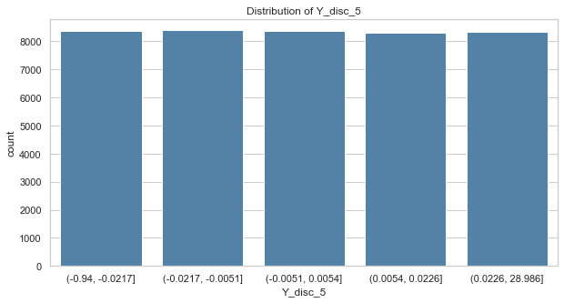

```python
df_target = df_target[~df_target["text"].isna()]
df_target['Y_disc_5'] = pd.qcut(df_target['Y_cont'], q = 5) # discretize

# Discretize without labels (for plot)
plt.rcParams["figure.figsize"] = [10,5]
p = sns.countplot(x = "Y_disc_5", data = df_target, color = "steelblue")
plt.title("Distribution of Y_disc_5")
plt.show(p)

# Discretize with labels
labels = ['lg_dec', 'sm_dec', 'same', 'sm_inc', 'lg_inc']
df_target['Y_disc_5'] = pd.qcut(df_target['Y_cont'], q = 5, labels = labels)
```

```python
# Split into training and validation
df_sub = df_target.loc[df_target["qtr"] != "2019-QTR1", :]
X = df_sub["text"]
y = df_sub["Y_disc_5"]
idx = df_sub.index.to_numpy()
X_tr, X_va, y_tr, y_va, idx_tr, idx_va = train_test_split(X, y, idx,
                                                          test_size = 0.2,
                                                          random_state = 1)

df_target["data_type"] = "test"
df_target.loc[idx_tr, "data_type"] = "training"
df_target.loc[idx_va, "data_type"] = "validation"

print(df_target.shape)
print(df_target.groupby("data_type").size())
```

```python
# Export modified data (all data; with outliers removed)
df_target = df_target.loc[df_target["Y_cont"] < 5]
df_target.to_csv("input/adj/target_withalltext_withevents_withtarget.csv", index = False)
```

```python
# Export modified data: processed, processed with negation, raw(separately)

df_text = df_target.drop(columns = ["raw", "text_neg"])
df_text.to_csv("input/adj/target_withtext_withevents_withtarget.csv", index = False)

df_text = df_target.drop(columns = ["raw", "text"])
df_text.to_csv("input/adj/target_withtextneg_withevents_withtarget.csv", index = False)

df_raw = df_target.drop(columns = ["text", "text_neg"])
df_raw.to_csv("input/adj/target_withraw_withevents_withtarget.csv", index = False)
```

# 6. Exploratory Analysis

```python
# Import Data
zf = zipfile.ZipFile("{}/input.zip".format(base_path))
df = pd.read_csv(zf.open('target_withtext_withevents_withtarget.csv'))
labels = ['lg_dec', 'sm_dec', 'same', 'sm_inc', 'lg_inc']
```

```python
from pylab import figure, axes, pie, title, show

def perc(n):
  def percentile_(x):
      return np.percentile(x, n)
  percentile_.__name__ = 'percentile_%s' % n
  return percentile_
```

## 6.1 Target Variable

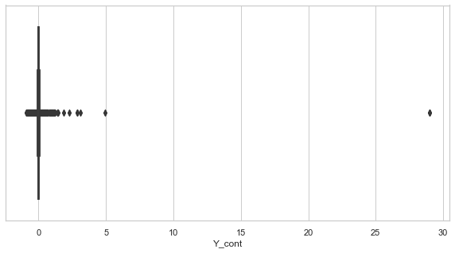

```
count    41765.000000
mean         0.002574
std          0.214415
min         -0.938600
25%         -0.015900
50%          0.000100
75%          0.016400
max         28.986300
Name: Y_cont, dtype: float64
```

```python
ax = sns.boxplot(x=df["Y_cont"])

# Show distribution of Y_cont
plt.rcParams["figure.figsize"] = [10,5]
ax = sns.boxplot(x=df["Y_cont"], color=sns.color_palette("Greys").as_hex()[4])
plt.show();

print(df["Y_cont"].describe())
```

```python
# Check and remove 2 outliers (now already removed in previous section)
display(df.loc[df["Y_cont"] > 5])

print(df.shape)
df = df.loc[df["Y_cont"] < 5]
print(df.shape)
```

|  | CIK | Ticker | Date Filed | Company Name | Form Type | Filename | Name | Exchange | SIC | Business | ... | Item 5.07 | Item 5.08 | Item 6.01 | Item 7.01 | Item 8.01 | Item 9.01 | sp_500 | Y_cont_notnormalized | Y_disc_5 | data_type |
| --- | --- | --- | --- | --- | --- | --- | --- | --- | --- | --- | --- | --- | --- | --- | --- | --- | --- | --- | --- | --- | --- |
| 27297 | 1463959 | DSKX | 2018-04-26 | DS HEALTHCARE GROUP, INC. | 8-K | edgar/data/1463959/0001553350-18-000416.txt | DS Healthcare Group Inc | NASDAQ | 2844.0 | FL | ... | False | False | False | False | False | False | 0.0137 | 29.0 | lg_inc | training |
| 27298 | 1463959 | DSKX | 2018-04-26 | DS HEALTHCARE GROUP, INC. | 8-K | edgar/data/1463959/0001553350-18-000420.txt | DS Healthcare Group Inc | NASDAQ | 2844.0 | FL | ... | False | False | False | False | False | False | 0.0137 | 29.0 | lg_inc | training |

2 rows × 97 columns

```
(41765, 97)
(41763, 97)
```

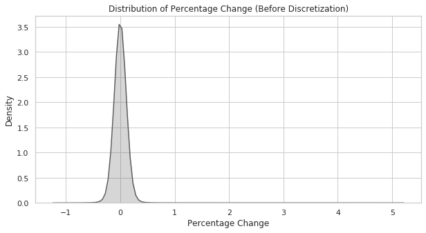

```
count    41763.000000
mean         0.001186
std          0.075784
min         -0.938600
25%         -0.015900
50%          0.000100
75%          0.016400
max          4.910500
Name: Y_cont, dtype: float64
```

```python
# Show distribution of Y_cont
plt.rcParams["figure.figsize"] = [10,5]
p = sns.kdeplot(df["Y_cont"], shade=True, bw=0.1, legend=False,
            color=sns.color_palette("Greys").as_hex()[4])
p.set(ylabel = "Density",
      xlabel = "Percentage Change",
      title = "Distribution of Percentage Change (Before Discretization)")

plt.show(p);
fig = p.get_figure()
fig.savefig("{}/figures/dist_target_nondisc.png".format(base_path),
            bbox_inches = "tight")

print(df["Y_cont"].describe())
```

```python
df_temp = df.groupby('data_type')['Y_cont'].\
          agg(['size','min','max','mean', perc(25), perc(50), perc(75), 'std'])
df_temp = df_temp.append(df['Y_cont'].describe().to_frame().transpose().\
                            rename(columns = {'count': 'size',
                                              '25%': 'percentile_25',
                                              '50%': 'percentile_50',
                                              '75%': 'percentile_75'},
                                   index = {'Y_cont': 'total'}).\
                            loc[:, ['size','min','max','mean', 'percentile_25',
                                    'percentile_50', 'percentile_75', 'std']])
df_temp = df_temp.loc[["training", "validation", "test", "total"], :].round(4)
display(df_temp)
print(df_temp.to_latex())
```

|  | size | min | max | mean | percentile_25 | percentile_50 | percentile_75 | std |
| --- | --- | --- | --- | --- | --- | --- | --- | --- |
| training | 27030.0 | -0.9386 | 4.9105 | 0.0008 | -0.0159 | 0.0001 | 0.0163 | 0.0760 |
| validation | 6758.0 | -0.9206 | 3.0863 | 0.0017 | -0.0155 | 0.0004 | 0.0175 | 0.0746 |
| test | 7975.0 | -0.8135 | 2.8866 | 0.0021 | -0.0163 | -0.0001 | 0.0157 | 0.0759 |
| total | 41763.0 | -0.9386 | 4.9105 | 0.0012 | -0.0159 | 0.0001 | 0.0164 | 0.0758 |

```
\begin{tabular}{lrrrrrrrr}
\toprule
{} &     size &     min &     max &    mean &  percentile\_25 &  percentile\_50 &  percentile\_75 &     std \\
\midrule
training   &  27030.0 & -0.9386 &  4.9105 &  0.0008 &        -0.0159 &         0.0001 &         0.0163 &  0.0760 \\
validation &   6758.0 & -0.9206 &  3.0863 &  0.0017 &        -0.0155 &         0.0004 &         0.0175 &  0.0746 \\
test       &   7975.0 & -0.8135 &  2.8866 &  0.0021 &        -0.0163 &        -0.0001 &         0.0157 &  0.0759 \\
total      &  41763.0 & -0.9386 &  4.9105 &  0.0012 &        -0.0159 &         0.0001 &         0.0164 &  0.0758 \\
\bottomrule
\end{tabular}
```

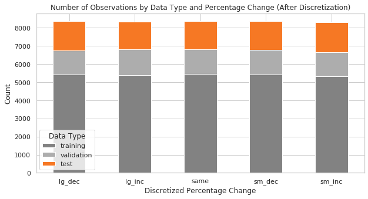

```python
colors = [sns.color_palette("Greys").as_hex()[3],
          sns.color_palette("Greys").as_hex()[2],
          sns.color_palette("Oranges").as_hex()[3]]
df_temp = df.rename(columns = {'data_type': "Data Type"}).\
          groupby(["Y_disc_5"])['Data Type'].value_counts(normalize=False).unstack()
df_temp = df_temp.loc[:, ["training", "validation", "test"]]

plt.rcParams["figure.figsize"] = [10,5]
p = df_temp.plot(kind='bar', stacked='True', color=colors);
plt.xlabel('Discretized Percentage Change');
plt.ylabel('Count');
plt.title('Number of Observations by Data Type and Percentage Change (After Discretization)');
plt.xticks(rotation=0);

plt.show(p);
fig = p.get_figure()
fig.savefig("{}/figures/dist_target_disc.png".format(base_path),
            bbox_inches = "tight")
```

```python
df_temp = df.rename(columns = {'Y_disc_5': 'Target'}).groupby('Target')['Y_cont'].\
          agg(['size','min','max','mean','median', 'std']).round(4)
display(df_temp)
print(df_temp.to_latex())
```

| Target | size | min | max | mean | median | std |
| --- | --- | --- | --- | --- | --- | --- |
| lg_dec | 8355 | -0.9386 | -0.0217 | -0.0681 | -0.0451 | 0.0687 |
| lg_inc | 8342 | 0.0227 | 4.9105 | 0.0736 | 0.0473 | 0.1166 |
| same | 8365 | -0.0051 | 0.0054 | 0.0002 | 0.0002 | 0.0030 |
| sm_dec | 8386 | -0.0217 | -0.0051 | -0.0121 | -0.0116 | 0.0047 |
| sm_inc | 8315 | 0.0054 | 0.0226 | 0.0126 | 0.0119 | 0.0048 |

```
\begin{tabular}{lrrrrrr}
\toprule
{} &  size &     min &     max &    mean &  median &     std \\
Target &       &         &         &         &         &         \\
\midrule
lg\_dec &  8355 & -0.9386 & -0.0217 & -0.0681 & -0.0451 &  0.0687 \\
lg\_inc &  8342 &  0.0227 &  4.9105 &  0.0736 &  0.0473 &  0.1166 \\
same   &  8365 & -0.0051 &  0.0054 &  0.0002 &  0.0002 &  0.0030 \\
sm\_dec &  8386 & -0.0217 & -0.0051 & -0.0121 & -0.0116 &  0.0047 \\
sm\_inc &  8315 &  0.0054 &  0.0226 &  0.0126 &  0.0119 &  0.0048 \\
\bottomrule
\end{tabular}
```

## 6.2 Other

**Number of words per Document**

For each document, we compute the total number of tokens. Then, we plot the distribution of the number of words. We can see that the majority of documents only contains relatively few tokens and that relatively few documents contain very many tokens (up to approx. 70K tokens). The vast majority of documents contain up to 10K tokens.

```python
num_token = df.text.apply(lambda x: len(x.split(" ")))
```

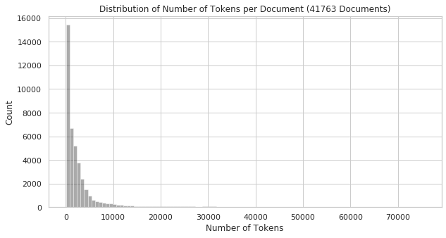

```python
%matplotlib inline
plt.rcParams["figure.figsize"] = [10,5]
p = sns.distplot(a = num_token, bins = 100, norm_hist = False, kde=False,
                  color = sns.color_palette("Greys").as_hex()[5])
plt.title("Distribution of Number of Tokens per Document ({} Documents)".format(num_token.shape[0]))
plt.ylabel("Count")
plt.xlabel("Number of Tokens")
plt.show(p)

plt.show(p);
fig = p.get_figure()
fig.savefig("{}/figures/dist_num_tokens.png".format(base_path),
             bbox_inches = "tight")
```

```python
describe(num_token, axis = None)
```

```
DescribeResult(nobs=41763, minmax=(113, 75438), mean=3768.104350741087, variance=58725360.435401544, skewness=4.603217404589945, kurtosis=24.91982216842254)
```

**Number of occurences per 8-K event**

```python
df_sub = df
df_sub = df_sub.loc[:, df_sub.columns.str.startswith(("Item"))].sum(axis = 0)
df_sub = df_sub.reset_index().rename(columns = {'index': 'Item', 0: 'Count'})
df_sub = df_sub.sort_values("Item")
```

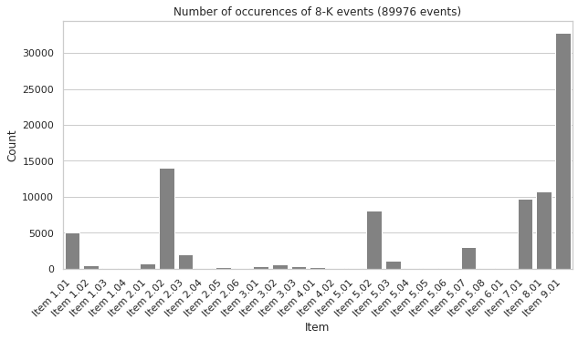

```python
plt.rcParams["figure.figsize"] = [10,5]
p = sns.barplot(x = "Item", y = "Count", data = df_sub,
                palette = [sns.color_palette("Greys").as_hex()[3]])
p.set_xticklabels(p.get_xticklabels(), rotation = 45, horizontalalignment='right')
plt.title("Number of occurences of 8-K events ({} events)".format(df_sub["Count"].sum()))
plt.show(p)

plt.show(p);
fig = p.get_figure()
fig.savefig("{}/figures/dist_8k_events.png".format(base_path),
            bbox_inches = "tight")
```

**Number of percentage change classes per 8-K event**

```python
df_sub = df
df_sub = df_sub.loc[:, df_sub.columns.str.startswith(("Item", "Y_disc_5"))]\
                .groupby("Y_disc_5").sum()
df_sub = pd.melt(df_sub.reset_index(), id_vars = "Y_disc_5",
                 value_vars = df_sub.columns.to_list()).\
                 rename(columns = {"value": "Count", "Y_disc_5": "Class",
                                   "variable": "8-K event"})
df_sub.head()
```

|  | Class | 8-K event | Count |
| --- | --- | --- | --- |
| 0 | lg_dec | Item 1.01 | 891.0 |
| 1 | lg_inc | Item 1.01 | 982.0 |
| 2 | same | Item 1.01 | 1008.0 |
| 3 | sm_dec | Item 1.01 | 1060.0 |
| 4 | sm_inc | Item 1.01 | 1027.0 |

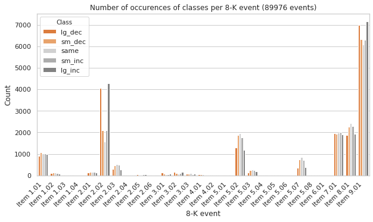

```python
colors = {'lg_inc': sns.color_palette("Greys").as_hex()[3],
          'sm_inc': sns.color_palette("Greys").as_hex()[2],
          'same': sns.color_palette("Greys").as_hex()[1],
          'sm_dec': sns.color_palette("Oranges").as_hex()[2],
          'lg_dec': sns.color_palette("Oranges").as_hex()[3]}

plt.rcParams["figure.figsize"] = [10,5]
p = sns.barplot(x = "8-K event", y = "Count", data = df_sub, hue = "Class",
                hue_order = ["lg_dec", "sm_dec", "same", "sm_inc", "lg_inc"],
                palette = colors)
p.set_xticklabels(p.get_xticklabels(), rotation = 45, horizontalalignment='right')
plt.title("Number of occurences of classes per 8-K event ({} events)".\
          format(int(df_sub["Count"].sum())))
plt.show(p)

plt.show(p);
fig = p.get_figure()
fig.savefig("{}/figures/dist_class_by_8k.png".format(base_path),
            bbox_inches = "tight")
```

**Number of Documents per Token**

For each token, we compute the number of documents in which the token occurs. Then, we plot the distribution of the number of documents per token. We can see that the majority of tokens only occurs in a small percentage of documents and that relatively few tokens occur in a large percentage of documents.

```python
vectorizer = CountVectorizer(binary = True)
documents = vectorizer.fit_transform(df.text)
document_counts = documents.sum(axis = 0)
document_counts = np.array(document_counts).reshape(document_counts.shape[1], )
```

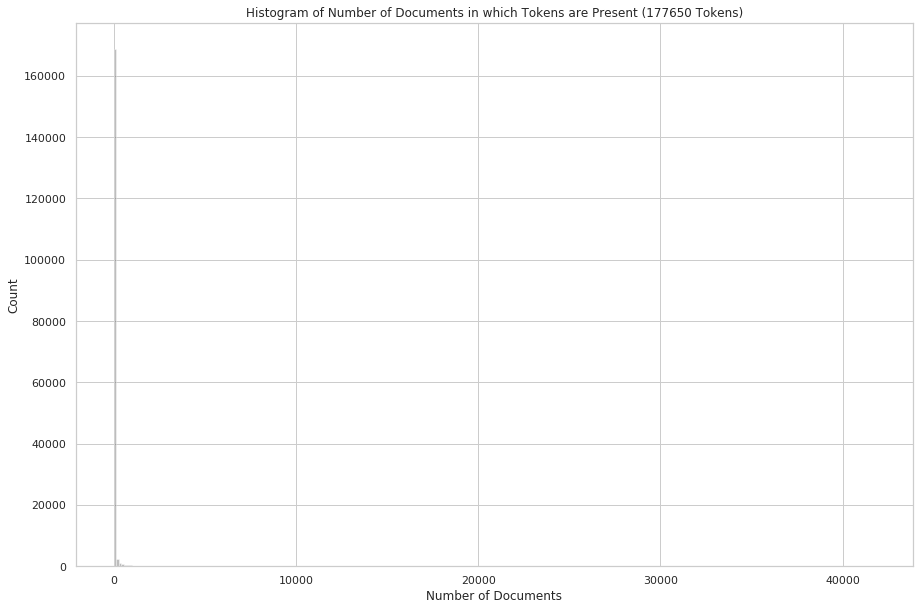

```python
%matplotlib inline
plt.rcParams["figure.figsize"] = [15,10]
p = sns.distplot(a = document_counts, bins = 300, norm_hist = False, kde=False,
                  color = sns.color_palette("Greys").as_hex()[4])
plt.title("Histogram of Number of Documents in which Tokens are Present ({} Tokens)".format(document_counts.shape[0]))
plt.ylabel("Count")
plt.xlabel("Number of Documents")
plt.show(p)
```

# 7. Baseline

There are various different, relatively simple models that we might try for this task: e.g. naive Bayes, logistic regression, support vector machines, or even decision trees.

```python
# Import Data
zf = zipfile.ZipFile("{}/input.zip".format(base_path))
df = pd.read_csv(zf.open('target_withtext_withevents_withtarget.csv'))
df_tr = df.loc[df["data_type"] == "training"]
df_va = df.loc[df["data_type"] == "validation"]

labels = ['lg_dec', 'sm_dec', 'same', 'sm_inc', 'lg_inc']
print(df.shape)
print(df_va.shape)
print(df_tr.shape)

X_tr = df_tr.text
y_tr = df_tr.Y_disc_5
X_va = df_va.text
y_va = df_va.Y_disc_5
```

```
(41763, 97)
(6756, 97)
(27032, 97)
```

## 7.1 Random Guess and Majority Class

On training data:

```python
# Random guess: 20% since we have 5 classes
print("Random guess accuracy: {}".format(1/len(np.unique(y_tr))))
```

```
Random guess accuracy: 0.2
```

```python
# Majority class: almost 20% since 5 classes are almost equally frequent
unique, pos = np.unique(y_tr, return_inverse=True)
counts = np.bincount(pos)
maxpos = counts.argmax()
acc = counts[maxpos]/np.sum(counts)
print("Majority class accuracy: {}".format(round(acc, 4)))
```

```
Majority class accuracy: 0.2022
```

On validation data:

```python
# Random guess: 20% since we have 5 classes
print("Random guess accuracy: {}".format(1/len(np.unique(y_va))))
```

```
Random guess accuracy: 0.2
```

```python
# Majority class: almost 20% since 5 classes are almost equally frequent
unique, pos = np.unique(y_va, return_inverse=True)
counts = np.bincount(pos)
maxpos = counts.argmax()
acc = counts[maxpos]/np.sum(counts)
print("Majority class accuracy: {}".format(round(acc, 4)))
```

```
Majority class accuracy: 0.2029
```

## 7.2 Naive Bayes

```python
# Define, train, predict and evaluate
steps = [('CountVectorizer', CountVectorizer(max_df = 0.9, min_df = 0.001)),
         ('MultinomialNB', MultinomialNB())]
model = Pipeline(steps)
model.fit(X_tr, y_tr)

pred = model.predict(X_tr)
evaluate(y_tr, pred, labels)
pred = model.predict(X_va)
evaluate(y_va, pred, labels)
```

```
Confusion matrix (absolute):
```

|  |  | Predicted lg_dec | Predicted sm_dec | Predicted same | Predicted sm_inc | Predicted lg_inc |
| --- | --- | --- | --- | --- | --- | --- |
| True | lg_dec | 3385 | 319 | 547 | 503 | 608 |
|  | sm_dec | 2097 | 645 | 1044 | 929 | 750 |
|  | same | 1857 | 367 | 1489 | 940 | 743 |
|  | sm_inc | 2112 | 387 | 953 | 1190 | 789 |
|  | lg_inc | 2407 | 270 | 533 | 438 | 1730 |

```
Confusion matrix (relative):
```

|  |  | Predicted lg_dec | Predicted sm_dec | Predicted same | Predicted sm_inc | Predicted lg_inc |
| --- | --- | --- | --- | --- | --- | --- |
| True | lg_dec | 12.52 | 1.18 | 2.02 | 1.86 | 2.25 |
|  | sm_dec | 7.76 | 2.39 | 3.86 | 3.44 | 2.77 |
|  | same | 6.87 | 1.36 | 5.51 | 3.48 | 2.75 |
|  | sm_inc | 7.81 | 1.43 | 3.53 | 4.40 | 2.92 |
|  | lg_inc | 8.90 | 1.00 | 1.97 | 1.62 | 6.40 |

```
Classification report:

              precision    recall  f1-score   support

      lg_dec       0.29      0.63      0.39      5362
      lg_inc       0.37      0.32      0.35      5378
        same       0.33      0.28      0.30      5396
      sm_dec       0.32      0.12      0.17      5465
      sm_inc       0.30      0.22      0.25      5431

    accuracy                           0.31     27032
   macro avg       0.32      0.31      0.29     27032
weighted avg       0.32      0.31      0.29     27032

Overall accuracy: 0.3122
Overall f1_score: 0.2922

Confusion matrix (absolute):
```

|  |  | Predicted lg_dec | Predicted sm_dec | Predicted same | Predicted sm_inc | Predicted lg_inc |
| --- | --- | --- | --- | --- | --- | --- |
| True | lg_dec | 716 | 96 | 134 | 131 | 276 |
|  | sm_dec | 512 | 106 | 273 | 257 | 190 |
|  | same | 423 | 127 | 320 | 273 | 188 |
|  | sm_inc | 542 | 99 | 268 | 256 | 198 |
|  | lg_inc | 721 | 75 | 154 | 126 | 295 |

```
Confusion matrix (relative):
```

|  |  | Predicted lg_dec | Predicted sm_dec | Predicted same | Predicted sm_inc | Predicted lg_inc |
| --- | --- | --- | --- | --- | --- | --- |
| True | lg_dec | 10.60 | 1.42 | 1.98 | 1.94 | 4.09 |
|  | sm_dec | 7.58 | 1.57 | 4.04 | 3.80 | 2.81 |
|  | same | 6.26 | 1.88 | 4.74 | 4.04 | 2.78 |
|  | sm_inc | 8.02 | 1.47 | 3.97 | 3.79 | 2.93 |
|  | lg_inc | 10.67 | 1.11 | 2.28 | 1.87 | 4.37 |

```
Classification report:

              precision    recall  f1-score   support

      lg_dec       0.25      0.53      0.34      1353
      lg_inc       0.26      0.22      0.23      1371
        same       0.28      0.24      0.26      1331
      sm_dec       0.21      0.08      0.12      1338
      sm_inc       0.25      0.19      0.21      1363

    accuracy                           0.25      6756
   macro avg       0.25      0.25      0.23      6756
weighted avg       0.25      0.25      0.23      6756

Overall accuracy: 0.2506
Overall f1_score: 0.2313
```

## 7.3 Random Forrest

```python
# Define, train, predict and evaluate
steps = [('CountVectorizer', CountVectorizer(max_df = 0.9, min_df = 0.001)),
         ('RandomForestClassifier', RandomForestClassifier())]
model = Pipeline(steps)
model.fit(X_tr, y_tr)

pred = model.predict(X_tr)
evaluate(y_tr, pred, labels)
pred = model.predict(X_va)
evaluate(y_va, pred, labels)
```

```
Confusion matrix (absolute):
```

|  |  | Predicted lg_dec | Predicted sm_dec | Predicted same | Predicted sm_inc | Predicted lg_inc |
| --- | --- | --- | --- | --- | --- | --- |
| True | lg_dec | 5305 | 11 | 8 | 18 | 20 |
|  | sm_dec | 28 | 5339 | 48 | 18 | 32 |
|  | same | 25 | 19 | 5313 | 14 | 25 |
|  | sm_inc | 30 | 28 | 37 | 5302 | 34 |
|  | lg_inc | 48 | 14 | 9 | 16 | 5291 |

```
Confusion matrix (relative):
```

|  |  | Predicted lg_dec | Predicted sm_dec | Predicted same | Predicted sm_inc | Predicted lg_inc |
| --- | --- | --- | --- | --- | --- | --- |
| True | lg_dec | 19.62 | 0.04 | 0.03 | 0.07 | 0.07 |
|  | sm_dec | 0.10 | 19.75 | 0.18 | 0.07 | 0.12 |
|  | same | 0.09 | 0.07 | 19.65 | 0.05 | 0.09 |
|  | sm_inc | 0.11 | 0.10 | 0.14 | 19.61 | 0.13 |
|  | lg_inc | 0.18 | 0.05 | 0.03 | 0.06 | 19.57 |

```
Classification report:

              precision    recall  f1-score   support

      lg_dec       0.98      0.99      0.98      5362
      lg_inc       0.98      0.98      0.98      5378
        same       0.98      0.98      0.98      5396
      sm_dec       0.99      0.98      0.98      5465
      sm_inc       0.99      0.98      0.98      5431

    accuracy                           0.98     27032
   macro avg       0.98      0.98      0.98     27032
weighted avg       0.98      0.98      0.98     27032

Overall accuracy: 0.9822
Overall f1_score: 0.9822

Confusion matrix (absolute):
```

|  |  | Predicted lg_dec | Predicted sm_dec | Predicted same | Predicted sm_inc | Predicted lg_inc |
| --- | --- | --- | --- | --- | --- | --- |
| True | lg_dec | 455 | 185 | 198 | 165 | 350 |
|  | sm_dec | 228 | 289 | 364 | 239 | 218 |
|  | same | 205 | 273 | 425 | 264 | 164 |
|  | sm_inc | 240 | 254 | 368 | 278 | 223 |
|  | lg_inc | 434 | 189 | 182 | 149 | 417 |

```
Confusion matrix (relative):
```

|  |  | Predicted lg_dec | Predicted sm_dec | Predicted same | Predicted sm_inc | Predicted lg_inc |
| --- | --- | --- | --- | --- | --- | --- |
| True | lg_dec | 6.73 | 2.74 | 2.93 | 2.44 | 5.18 |
|  | sm_dec | 3.37 | 4.28 | 5.39 | 3.54 | 3.23 |
|  | same | 3.03 | 4.04 | 6.29 | 3.91 | 2.43 |
|  | sm_inc | 3.55 | 3.76 | 5.45 | 4.11 | 3.30 |
|  | lg_inc | 6.42 | 2.80 | 2.69 | 2.21 | 6.17 |

```
Classification report:

              precision    recall  f1-score   support

      lg_dec       0.29      0.34      0.31      1353
      lg_inc       0.30      0.30      0.30      1371
        same       0.28      0.32      0.30      1331
      sm_dec       0.24      0.22      0.23      1338
      sm_inc       0.25      0.20      0.23      1363

    accuracy                           0.28      6756
   macro avg       0.27      0.28      0.27      6756
weighted avg       0.27      0.28      0.27      6756

Overall accuracy: 0.2759
Overall f1_score: 0.2735
```

## 7.4 Logistic Regression

```python
# Define, train, predict and evaluate
steps = [('CountVectorizer', CountVectorizer(max_df = 0.9, min_df = 0.001)),
         ('LogisticRegression', LogisticRegression(solver = "lbfgs"))]
model = Pipeline(steps)
model.fit(X_tr, y_tr)

pred = model.predict(X_tr)
evaluate(y_tr, pred, labels)
pred = model.predict(X_va)
evaluate(y_va, pred, labels)
```

```
Confusion matrix (absolute):
```

|  |  | Predicted lg_dec | Predicted sm_dec | Predicted same | Predicted sm_inc | Predicted lg_inc |
| --- | --- | --- | --- | --- | --- | --- |
| True | lg_dec | 2285 | 502 | 777 | 821 | 977 |
|  | sm_dec | 577 | 1715 | 1367 | 1191 | 615 |
|  | same | 397 | 677 | 2636 | 1221 | 465 |
|  | sm_inc | 519 | 708 | 1280 | 2270 | 654 |
|  | lg_inc | 885 | 437 | 762 | 764 | 2530 |

```
Confusion matrix (relative):
```

|  |  | Predicted lg_dec | Predicted sm_dec | Predicted same | Predicted sm_inc | Predicted lg_inc |
| --- | --- | --- | --- | --- | --- | --- |
| True | lg_dec | 8.45 | 1.86 | 2.87 | 3.04 | 3.61 |
|  | sm_dec | 2.13 | 6.34 | 5.06 | 4.41 | 2.28 |
|  | same | 1.47 | 2.50 | 9.75 | 4.52 | 1.72 |
|  | sm_inc | 1.92 | 2.62 | 4.74 | 8.40 | 2.42 |
|  | lg_inc | 3.27 | 1.62 | 2.82 | 2.83 | 9.36 |

```
Classification report:

              precision    recall  f1-score   support

      lg_dec       0.49      0.43      0.46      5362
      lg_inc       0.48      0.47      0.48      5378
        same       0.39      0.49      0.43      5396
      sm_dec       0.42      0.31      0.36      5465
      sm_inc       0.36      0.42      0.39      5431

    accuracy                           0.42     27032
   macro avg       0.43      0.42      0.42     27032
weighted avg       0.43      0.42      0.42     27032

Overall accuracy: 0.4231
Overall f1_score: 0.4223

Confusion matrix (absolute):
```

|  |  | Predicted lg_dec | Predicted sm_dec | Predicted same | Predicted sm_inc | Predicted lg_inc |
| --- | --- | --- | --- | --- | --- | --- |
| True | lg_dec | 407 | 152 | 212 | 225 | 357 |
|  | sm_dec | 174 | 222 | 433 | 350 | 159 |
|  | same | 118 | 250 | 444 | 382 | 137 |
|  | sm_inc | 156 | 225 | 417 | 376 | 189 |
|  | lg_inc | 330 | 137 | 214 | 204 | 486 |

```
Confusion matrix (relative):
```

|  |  | Predicted lg_dec | Predicted sm_dec | Predicted same | Predicted sm_inc | Predicted lg_inc |
| --- | --- | --- | --- | --- | --- | --- |
| True | lg_dec | 6.02 | 2.25 | 3.14 | 3.33 | 5.28 |
|  | sm_dec | 2.58 | 3.29 | 6.41 | 5.18 | 2.35 |
|  | same | 1.75 | 3.70 | 6.57 | 5.65 | 2.03 |
|  | sm_inc | 2.31 | 3.33 | 6.17 | 5.57 | 2.80 |
|  | lg_inc | 4.88 | 2.03 | 3.17 | 3.02 | 7.19 |

```
Classification report:

              precision    recall  f1-score   support

      lg_dec       0.34      0.30      0.32      1353
      lg_inc       0.37      0.35      0.36      1371
        same       0.26      0.33      0.29      1331
      sm_dec       0.23      0.17      0.19      1338
      sm_inc       0.24      0.28      0.26      1363

    accuracy                           0.29      6756
   macro avg       0.29      0.29      0.28      6756
weighted avg       0.29      0.29      0.28      6756

Overall accuracy: 0.2864
Overall f1_score: 0.2848
```

## 7.5 Support Vector Machine

```python
# Define, train, predict and evaluate
steps = [('CountVectorizer', CountVectorizer(max_df = 0.9, min_df = 0.001)),
         ('SGDClassifier', SGDClassifier())]
model = Pipeline(steps)
model.fit(X_tr, y_tr)

pred = model.predict(X_tr)
evaluate(y_tr, pred, labels)
pred = model.predict(X_va)
evaluate(y_va, pred, labels)
```

```
Confusion matrix (absolute):
```

|  |  | Predicted lg_dec | Predicted sm_dec | Predicted same | Predicted sm_inc | Predicted lg_inc |
| --- | --- | --- | --- | --- | --- | --- |
| True | lg_dec | 2253 | 606 | 1165 | 398 | 940 |
|  | sm_dec | 456 | 1856 | 1905 | 554 | 694 |
|  | same | 380 | 667 | 3235 | 564 | 550 |
|  | sm_inc | 511 | 760 | 1873 | 1446 | 841 |
|  | lg_inc | 753 | 497 | 1116 | 305 | 2707 |

```
Confusion matrix (relative):
```

|  |  | Predicted lg_dec | Predicted sm_dec | Predicted same | Predicted sm_inc | Predicted lg_inc |
| --- | --- | --- | --- | --- | --- | --- |
| True | lg_dec | 8.33 | 2.24 | 4.31 | 1.47 | 3.48 |
|  | sm_dec | 1.69 | 6.87 | 7.05 | 2.05 | 2.57 |
|  | same | 1.41 | 2.47 | 11.97 | 2.09 | 2.03 |
|  | sm_inc | 1.89 | 2.81 | 6.93 | 5.35 | 3.11 |
|  | lg_inc | 2.79 | 1.84 | 4.13 | 1.13 | 10.01 |

```
Classification report:

              precision    recall  f1-score   support

      lg_dec       0.52      0.42      0.46      5362
      lg_inc       0.47      0.50      0.49      5378
        same       0.35      0.60      0.44      5396
      sm_dec       0.42      0.34      0.38      5465
      sm_inc       0.44      0.27      0.33      5431

    accuracy                           0.43     27032
   macro avg       0.44      0.43      0.42     27032
weighted avg       0.44      0.43      0.42     27032

Overall accuracy: 0.4253
Overall f1_score: 0.4198

Confusion matrix (absolute):
```

|  |  | Predicted lg_dec | Predicted sm_dec | Predicted same | Predicted sm_inc | Predicted lg_inc |
| --- | --- | --- | --- | --- | --- | --- |
| True | lg_dec | 320 | 213 | 327 | 139 | 354 |
|  | sm_dec | 151 | 247 | 511 | 215 | 214 |
|  | same | 116 | 224 | 585 | 213 | 193 |
|  | sm_inc | 180 | 238 | 515 | 193 | 237 |
|  | lg_inc | 292 | 210 | 336 | 119 | 414 |

```
Confusion matrix (relative):
```

|  |  | Predicted lg_dec | Predicted sm_dec | Predicted same | Predicted sm_inc | Predicted lg_inc |
| --- | --- | --- | --- | --- | --- | --- |
| True | lg_dec | 4.74 | 3.15 | 4.84 | 2.06 | 5.24 |
|  | sm_dec | 2.24 | 3.66 | 7.56 | 3.18 | 3.17 |
|  | same | 1.72 | 3.32 | 8.66 | 3.15 | 2.86 |
|  | sm_inc | 2.66 | 3.52 | 7.62 | 2.86 | 3.51 |
|  | lg_inc | 4.32 | 3.11 | 4.97 | 1.76 | 6.13 |

```
Classification report:

              precision    recall  f1-score   support

      lg_dec       0.30      0.24      0.27      1353
      lg_inc       0.29      0.30      0.30      1371
        same       0.26      0.44      0.32      1331
      sm_dec       0.22      0.18      0.20      1338
      sm_inc       0.22      0.14      0.17      1363

    accuracy                           0.26      6756
   macro avg       0.26      0.26      0.25      6756
weighted avg       0.26      0.26      0.25      6756

Overall accuracy: 0.2604
Overall f1_score: 0.2518
```

# 8. Catboost

## 8.1 Comparison: CountVectorizer vs. TfidfVectorizer

### 8.1.1 CountVectorizer

```python
# Import Data
zf = zipfile.ZipFile("{}/input.zip".format(base_path))
df = pd.read_csv(zf.open('target_withtext_withevents_withtarget.csv'))
df_tr = df.loc[df["data_type"] == "training"]
X = df_tr.text
y = df_tr.Y_disc_5

# Split training into training and validation data
X_tr, X_va, y_tr, y_va = train_test_split(X, y, test_size=0.33,
                                                    random_state=1)

labels = ['lg_dec', 'sm_dec', 'same', 'sm_inc', 'lg_inc']
print(df.shape)
print(df_tr.shape)

del [df, zf, X, y]
gc.collect();
```

```python
# Vectorize the text data
vectorizer = CountVectorizer(min_df = 0.001).fit(X_tr)
X_va = vectorizer.transform(X_va)
X_tr = vectorizer.transform(X_tr)
X_va = X_va.toarray()
X_tr = X_tr.toarray()
print("Dimension X_tr: {}".format(X_tr.shape))
print("Dimension X_va: {}".format(X_va.shape))

# Fit model
model = CatBoostClassifier(loss_function = 'MultiClass',
                           task_type = "GPU", verbose = 100)
model.fit(X_tr, y_tr)

# Evaluation on train data
data = Pool(X_tr, y_tr)
pred = model.predict(data).flatten()
evaluate(y_tr, pred, labels)

# Evaluation on test data
data = Pool(X_va, y_va)
pred = model.predict(data).flatten()
evaluate(y_va, pred, labels)
```

```
Dimension X_tr: (18111, 15943)
Dimension X_va: (8921, 15943)
0:	learn: 1.6061983	total: 86.1ms	remaining: 1m 26s
100:	learn: 1.5149176	total: 6.5s	remaining: 57.9s
200:	learn: 1.4934061	total: 11.6s	remaining: 46.3s
300:	learn: 1.4782869	total: 16.5s	remaining: 38.2s
400:	learn: 1.4643140	total: 21s	remaining: 31.4s
500:	learn: 1.4503149	total: 25.7s	remaining: 25.6s
600:	learn: 1.4373367	total: 30.4s	remaining: 20.2s
700:	learn: 1.4252527	total: 34.9s	remaining: 14.9s
800:	learn: 1.4132635	total: 39.6s	remaining: 9.84s
900:	learn: 1.4026502	total: 44.2s	remaining: 4.85s
999:	learn: 1.3923193	total: 48.7s	remaining: 0us

Confusion matrix (absolute):
```

|  |  | Predicted lg_dec | Predicted sm_dec | Predicted same | Predicted sm_inc | Predicted lg_inc |
| --- | --- | --- | --- | --- | --- | --- |
| True | lg_dec | 1552 | 365 | 710 | 288 | 613 |
|  | sm_dec | 298 | 1505 | 1218 | 221 | 443 |
|  | same | 203 | 280 | 2599 | 224 | 381 |
|  | sm_inc | 233 | 321 | 1178 | 1398 | 487 |
|  | lg_inc | 267 | 326 | 670 | 309 | 2022 |

```
Confusion matrix (relative):
```

|  |  | Predicted lg_dec | Predicted sm_dec | Predicted same | Predicted sm_inc | Predicted lg_inc |
| --- | --- | --- | --- | --- | --- | --- |
| True | lg_dec | 8.57 | 2.02 | 3.92 | 1.59 | 3.38 |
|  | sm_dec | 1.65 | 8.31 | 6.73 | 1.22 | 2.45 |
|  | same | 1.12 | 1.55 | 14.35 | 1.24 | 2.10 |
|  | sm_inc | 1.29 | 1.77 | 6.50 | 7.72 | 2.69 |
|  | lg_inc | 1.47 | 1.80 | 3.70 | 1.71 | 11.16 |

```
Classification report:

              precision    recall  f1-score   support

      lg_dec       0.61      0.44      0.51      3528
      lg_inc       0.51      0.56      0.54      3594
        same       0.41      0.70      0.52      3687
      sm_dec       0.54      0.41      0.46      3685
      sm_inc       0.57      0.39      0.46      3617

    accuracy                           0.50     18111
   macro avg       0.53      0.50      0.50     18111
weighted avg       0.53      0.50      0.50     18111

Overall accuracy: 0.5011
Overall f1_score: 0.4977

Confusion matrix (absolute):
```

|  |  | Predicted lg_dec | Predicted sm_dec | Predicted same | Predicted sm_inc | Predicted lg_inc |
| --- | --- | --- | --- | --- | --- | --- |
| True | lg_dec | 412 | 232 | 385 | 185 | 620 |
|  | sm_dec | 171 | 310 | 780 | 251 | 268 |
|  | same | 141 | 304 | 849 | 242 | 173 |
|  | sm_inc | 166 | 357 | 751 | 276 | 264 |
|  | lg_inc | 281 | 235 | 309 | 228 | 731 |

```
Confusion matrix (relative):
```

|  |  | Predicted lg_dec | Predicted sm_dec | Predicted same | Predicted sm_inc | Predicted lg_inc |
| --- | --- | --- | --- | --- | --- | --- |
| True | lg_dec | 4.62 | 2.60 | 4.32 | 2.07 | 6.95 |
|  | sm_dec | 1.92 | 3.47 | 8.74 | 2.81 | 3.00 |
|  | same | 1.58 | 3.41 | 9.52 | 2.71 | 1.94 |
|  | sm_inc | 1.86 | 4.00 | 8.42 | 3.09 | 2.96 |
|  | lg_inc | 3.15 | 2.63 | 3.46 | 2.56 | 8.19 |

```
Classification report:

              precision    recall  f1-score   support

      lg_dec       0.35      0.22      0.27      1834
      lg_inc       0.36      0.41      0.38      1784
        same       0.28      0.50      0.36      1709
      sm_dec       0.22      0.17      0.19      1780
      sm_inc       0.23      0.15      0.18      1814

    accuracy                           0.29      8921
   macro avg       0.29      0.29      0.28      8921
weighted avg       0.29      0.29      0.28      8921

Overall accuracy: 0.289
Overall f1_score: 0.2764
```

### 8.1.2 TfidfVectorizer

```python
# Import Data
zf = zipfile.ZipFile("{}/input.zip".format(base_path))
df = pd.read_csv(zf.open('target_withtext_withevents_withtarget.csv'))
df_tr = df.loc[df["data_type"] == "training"]
X = df_tr.text
y = df_tr.Y_disc_5

# Split training into training and validation data
X_tr, X_va, y_tr, y_va = train_test_split(X, y, test_size=0.33,
                                                    random_state=1)

labels = ['lg_dec', 'sm_dec', 'same', 'sm_inc', 'lg_inc']
print(df.shape)
print(df_tr.shape)

del [df, zf, X, y]
gc.collect();
```

```
(41763, 97)
(27032, 97)
```

```python
# Vectorize the text data
vectorizer = TfidfVectorizer(min_df=0.001).fit(X_tr)
X_va = vectorizer.transform(X_va)
X_tr = vectorizer.transform(X_tr)
X_va = X_va.toarray()
X_tr = X_tr.toarray()
print("Dimension X_tr: {}".format(X_tr.shape))
print("Dimension X_va: {}".format(X_va.shape))

# Fit model
model = CatBoostClassifier(loss_function = 'MultiClass',
                           task_type = "GPU", verbose = 100)
model.fit(X_tr, y_tr)

# Evaluation on train data
data = Pool(X_tr, y_tr)
pred = model.predict(data).flatten()
evaluate(y_tr, pred, labels)

# Evaluation on test data
data = Pool(X_va, y_va)
pred = model.predict(data).flatten()
evaluate(y_va, pred, labels)
```

```
Dimension X_tr: (18111, 15943)
Dimension X_va: (8921, 15943)
0:	learn: 1.6063098	total: 192ms	remaining: 3m 11s
100:	learn: 1.5118562	total: 13.9s	remaining: 2m 3s
200:	learn: 1.4863589	total: 25.8s	remaining: 1m 42s
300:	learn: 1.4687124	total: 37s	remaining: 1m 25s
400:	learn: 1.4514843	total: 48.3s	remaining: 1m 12s
500:	learn: 1.4353791	total: 59.3s	remaining: 59.1s
600:	learn: 1.4205708	total: 1m 10s	remaining: 46.7s
700:	learn: 1.4069928	total: 1m 21s	remaining: 34.6s
800:	learn: 1.3931532	total: 1m 32s	remaining: 22.9s
900:	learn: 1.3803199	total: 1m 42s	remaining: 11.3s
999:	learn: 1.3685790	total: 1m 53s	remaining: 0us

Confusion matrix (absolute):
```

|  |  | Predicted lg_dec | Predicted sm_dec | Predicted same | Predicted sm_inc | Predicted lg_inc |
| --- | --- | --- | --- | --- | --- | --- |
| True | lg_dec | 1739 | 391 | 603 | 284 | 511 |
|  | sm_dec | 306 | 1897 | 843 | 197 | 442 |
|  | same | 228 | 251 | 2637 | 206 | 365 |
|  | sm_inc | 252 | 363 | 898 | 1649 | 455 |
|  | lg_inc | 239 | 379 | 535 | 318 | 2123 |

```
Confusion matrix (relative):
```

|  |  | Predicted lg_dec | Predicted sm_dec | Predicted same | Predicted sm_inc | Predicted lg_inc |
| --- | --- | --- | --- | --- | --- | --- |
| True | lg_dec | 9.60 | 2.16 | 3.33 | 1.57 | 2.82 |
|  | sm_dec | 1.69 | 10.47 | 4.65 | 1.09 | 2.44 |
|  | same | 1.26 | 1.39 | 14.56 | 1.14 | 2.02 |
|  | sm_inc | 1.39 | 2.00 | 4.96 | 9.10 | 2.51 |
|  | lg_inc | 1.32 | 2.09 | 2.95 | 1.76 | 11.72 |

```
Classification report:

              precision    recall  f1-score   support

      lg_dec       0.63      0.49      0.55      3528
      lg_inc       0.54      0.59      0.57      3594
        same       0.48      0.72      0.57      3687
      sm_dec       0.58      0.51      0.54      3685
      sm_inc       0.62      0.46      0.53      3617

    accuracy                           0.55     18111
   macro avg       0.57      0.55      0.55     18111
weighted avg       0.57      0.55      0.55     18111

Overall accuracy: 0.5546
Overall f1_score: 0.5527

Confusion matrix (absolute):
```

|  |  | Predicted lg_dec | Predicted sm_dec | Predicted same | Predicted sm_inc | Predicted lg_inc |
| --- | --- | --- | --- | --- | --- | --- |
| True | lg_dec | 455 | 269 | 323 | 191 | 596 |
|  | sm_dec | 187 | 383 | 683 | 270 | 257 |
|  | same | 135 | 361 | 775 | 258 | 180 |
|  | sm_inc | 157 | 390 | 655 | 326 | 286 |
|  | lg_inc | 309 | 254 | 289 | 234 | 698 |

```
Confusion matrix (relative):
```

|  |  | Predicted lg_dec | Predicted sm_dec | Predicted same | Predicted sm_inc | Predicted lg_inc |
| --- | --- | --- | --- | --- | --- | --- |
| True | lg_dec | 5.10 | 3.02 | 3.62 | 2.14 | 6.68 |
|  | sm_dec | 2.10 | 4.29 | 7.66 | 3.03 | 2.88 |
|  | same | 1.51 | 4.05 | 8.69 | 2.89 | 2.02 |
|  | sm_inc | 1.76 | 4.37 | 7.34 | 3.65 | 3.21 |
|  | lg_inc | 3.46 | 2.85 | 3.24 | 2.62 | 7.82 |

```
Classification report:

              precision    recall  f1-score   support

      lg_dec       0.37      0.25      0.30      1834
      lg_inc       0.35      0.39      0.37      1784
        same       0.28      0.45      0.35      1709
      sm_dec       0.23      0.22      0.22      1780
      sm_inc       0.25      0.18      0.21      1814

    accuracy                           0.30      8921
   macro avg       0.30      0.30      0.29      8921
weighted avg       0.30      0.30      0.29      8921

Overall accuracy: 0.2956
Overall f1_score: 0.2885
```

## 8.2 Comparison: With vs. Without Negation Encoding

### 8.2.1 With Negation Encoding

```python
# Import Data
zf = zipfile.ZipFile("{}/input.zip".format(base_path))
df = pd.read_csv(zf.open('target_withtextneg_withevents_withtarget.csv'))
print(df.loc[(df["large"] == True) | (df["error"] == True), :].shape)
print(df.shape)

labels = ['lg_dec', 'sm_dec', 'same', 'sm_inc', 'lg_inc']

df = df.loc[(df["large"] != True) & (df["error"] != True), :]
df_tr = df.loc[df["data_type"] == "training"]
X = df_tr.text_neg
y = df_tr.Y_disc_5

# Split training into training and validation data
X_tr, X_va, y_tr, y_va = train_test_split(X, y, test_size=0.33,
                                                    random_state=1)

# Vectorize the text data
vectorizer = TfidfVectorizer(min_df=0.001).fit(X_tr)
X_va = vectorizer.transform(X_va)
X_tr = vectorizer.transform(X_tr)
X_va = X_va.toarray()
X_tr = X_tr.toarray()
print("Dimension X_tr: {}".format(X_tr.shape))
print("Dimension X_va: {}".format(X_va.shape))

# Fit model
from catboost import CatBoostClassifier, Pool
model = CatBoostClassifier(loss_function = 'MultiClass',
                           task_type = "GPU", verbose = 100)
model.fit(X_tr, y_tr)

# Evaluation on train data
data = catboost_pool = Pool(X_tr, y_tr)
pred = model.predict(data).flatten()
evaluate(y_tr, pred, labels)

# Evaluation on test data
data = catboost_pool = Pool(X_va, y_va)
pred = model.predict(data).flatten()
evaluate(y_va, pred, labels)
```

```
(2, 98)
(41763, 98)
Dimension X_tr: (22384, 20281)
Dimension X_va: (11026, 20281)
0:	learn: 1.6061572	total: 247ms	remaining: 4m 6s
100:	learn: 1.5104577	total: 19.6s	remaining: 2m 54s
200:	learn: 1.4874698	total: 36.4s	remaining: 2m 24s
300:	learn: 1.4714523	total: 52s	remaining: 2m
400:	learn: 1.4564091	total: 1m 7s	remaining: 1m 40s
500:	learn: 1.4418166	total: 1m 22s	remaining: 1m 22s
600:	learn: 1.4284152	total: 1m 37s	remaining: 1m 4s
700:	learn: 1.4159401	total: 1m 52s	remaining: 48.2s
800:	learn: 1.4043628	total: 2m 7s	remaining: 31.8s
900:	learn: 1.3932771	total: 2m 23s	remaining: 15.7s
999:	learn: 1.3827331	total: 2m 37s	remaining: 0us

Confusion matrix (absolute):
```

|  |  | Predicted lg_dec | Predicted sm_dec | Predicted same | Predicted sm_inc | Predicted lg_inc |
| --- | --- | --- | --- | --- | --- | --- |
| True | lg_dec | 2267 | 466 | 722 | 425 | 608 |
|  | sm_dec | 428 | 2116 | 1106 | 363 | 518 |
|  | same | 330 | 328 | 3004 | 376 | 411 |
|  | sm_inc | 387 | 418 | 1131 | 1967 | 563 |
|  | lg_inc | 424 | 424 | 644 | 450 | 2508 |

```
Confusion matrix (relative):
```

|  |  | Predicted lg_dec | Predicted sm_dec | Predicted same | Predicted sm_inc | Predicted lg_inc |
| --- | --- | --- | --- | --- | --- | --- |
| True | lg_dec | 10.13 | 2.08 | 3.23 | 1.90 | 2.72 |
|  | sm_dec | 1.91 | 9.45 | 4.94 | 1.62 | 2.31 |
|  | same | 1.47 | 1.47 | 13.42 | 1.68 | 1.84 |
|  | sm_inc | 1.73 | 1.87 | 5.05 | 8.79 | 2.52 |
|  | lg_inc | 1.89 | 1.89 | 2.88 | 2.01 | 11.20 |

```
Classification report:

              precision    recall  f1-score   support

      lg_dec       0.59      0.51      0.54      4488
      lg_inc       0.54      0.56      0.55      4450
        same       0.45      0.68      0.54      4449
      sm_dec       0.56      0.47      0.51      4531
      sm_inc       0.55      0.44      0.49      4466

    accuracy                           0.53     22384
   macro avg       0.54      0.53      0.53     22384
weighted avg       0.54      0.53      0.53     22384

Overall accuracy: 0.5299
Overall f1_score: 0.5283

Confusion matrix (absolute):
```

|  |  | Predicted lg_dec | Predicted sm_dec | Predicted same | Predicted sm_inc | Predicted lg_inc |
| --- | --- | --- | --- | --- | --- | --- |
| True | lg_dec | 667 | 313 | 361 | 294 | 619 |
|  | sm_dec | 305 | 427 | 791 | 344 | 313 |
|  | same | 203 | 409 | 1000 | 334 | 250 |
|  | sm_inc | 256 | 428 | 785 | 426 | 325 |
|  | lg_inc | 500 | 260 | 332 | 283 | 801 |

```
Confusion matrix (relative):
```

|  |  | Predicted lg_dec | Predicted sm_dec | Predicted same | Predicted sm_inc | Predicted lg_inc |
| --- | --- | --- | --- | --- | --- | --- |
| True | lg_dec | 6.05 | 2.84 | 3.27 | 2.67 | 5.61 |
|  | sm_dec | 2.77 | 3.87 | 7.17 | 3.12 | 2.84 |
|  | same | 1.84 | 3.71 | 9.07 | 3.03 | 2.27 |
|  | sm_inc | 2.32 | 3.88 | 7.12 | 3.86 | 2.95 |
|  | lg_inc | 4.53 | 2.36 | 3.01 | 2.57 | 7.26 |

```
Classification report:

              precision    recall  f1-score   support

      lg_dec       0.35      0.30      0.32      2254
      lg_inc       0.35      0.37      0.36      2176
        same       0.31      0.46      0.37      2196
      sm_dec       0.23      0.20      0.21      2180
      sm_inc       0.25      0.19      0.22      2220

    accuracy                           0.30     11026
   macro avg       0.30      0.30      0.29     11026
weighted avg       0.30      0.30      0.29     11026

Overall accuracy: 0.3012
Overall f1_score: 0.2946
```

### 8.2.2 Without Negation Encoding

See 8.1.2

## 8.3 Grid Search: min_df, max_df

```python
# Import Data
zf = zipfile.ZipFile("{}/input.zip".format(base_path))
df = pd.read_csv(zf.open('target_withtext_withevents_withtarget.csv'))
df_tr = df.loc[df["data_type"] == "training"]
labels = ['lg_dec', 'sm_dec', 'same', 'sm_inc', 'lg_inc']

# Check dimensions
print(df.shape)
print(df_tr.shape)

# Fetch data
X_tr = df_tr.text
y_tr = df_tr.Y_disc_5

# Free memory
del [df, zf, df_tr]
gc.collect();
```

```
(41763, 97)
(27032, 97)
```

```python
%%time

# Define, train, predict and evaluate with hyperparameter tuning
params = {'TfidfVectorizer__min_df': [0.001, 0.005, 0.01],
          'TfidfVectorizer__max_df': [0.85, 0.9, 0.95]}
steps = [('TfidfVectorizer', TfidfVectorizer()),
         ('CatBoostClassifier', CatBoostClassifier(loss_function = 'MultiClass',
                                              task_type = "GPU", verbose = False))]
model = Pipeline(steps)
model_cv = GridSearchCV(model, params, cv = 3, verbose = True)
model_cv.fit(X_tr, y_tr)
```

```
Fitting 3 folds for each of 9 candidates, totalling 27 fits
```

```
[Parallel(n_jobs=1)]: Using backend SequentialBackend with 1 concurrent workers.
[Parallel(n_jobs=1)]: Done  27 out of  27 | elapsed: 64.6min finished
```

```
CPU times: user 1h 1min 58s, sys: 28min 38s, total: 1h 30min 36s
Wall time: 1h 8min
```

```python
print("Best parameters:")
params = model_cv.best_params_
print(params)
```

```
Best parameters:
{'TfidfVectorizer__max_df': 0.9, 'TfidfVectorizer__min_df': 0.001}
```

```python
# Import Data
zf = zipfile.ZipFile("{}/input.zip".format(base_path))
df = pd.read_csv(zf.open('target_withtext_withevents_withtarget.csv'))
df_tr = df.loc[df["data_type"] == "training"]
labels = ['lg_dec', 'sm_dec', 'same', 'sm_inc', 'lg_inc']

# Fetch data
X_tr = df_tr.text
y_tr = df_tr.Y_disc_5

# Vectorize the text data
vectorizer = TfidfVectorizer(min_df=params["TfidfVectorizer__min_df"],
                             max_df=params["TfidfVectorizer__max_df"]).fit(X_tr)
X_tr = vectorizer.transform(X_tr)
X_tr = X_tr.toarray()

# Fit model
model = CatBoostClassifier(loss_function = 'MultiClass',
                           task_type = "GPU", verbose = 100)
model.fit(X_tr, y_tr)
```

## 8.4 Grid Search: n-grams (after removing irrelevant features)

```python
if not os.path.exists("{}/input/adj".format(base_path)):
    os.makedirs("{}/input/adj".format(base_path))
```

```python
# Save the feature importances from the previous model to file
feature_names = vectorizer.get_feature_names()
df_feat = pd.DataFrame({'Feature': feature_names, "Feature Id": list(range(len(feature_names)))})
df_feat_imp = model.get_feature_importance(prettified = True)
df_feat_imp["Feature Id"] = df_feat_imp["Feature Id"].astype(int)

df_feat = pd.merge(df_feat, df_feat_imp, on = "Feature Id")
df_feat = df_feat.sort_values("Importances", ascending = False)

df_feat.to_csv("{}/input/adj/feat_imp_ngrams.csv".format(base_path), index = False)
```

```python
# Import feature importances
df_feat = pd.read_csv("{}/input/adj/feat_imp_ngrams.csv".format(base_path))
print(df_feat.shape)
df_feat.head()
```

```
(15898, 3)
```

|  | Feature | Feature Id | Importances |
| --- | --- | --- | --- |
| 0 | banks | 1265 | 1.459993 |
| 1 | results | 12246 | 1.368124 |
| 2 | webcast | 15474 | 1.358748 |
| 3 | bank | 1257 | 1.019127 |
| 4 | sheets | 13002 | 1.017931 |

```python
# Keep all features with > 0.001 importance
df_feat = df_feat.loc[df_feat["Importances"] > 0.01, :]

# Extract the tokens
feat_keep = set(df_feat.Feature.to_list())
print(len(feat_keep))
```

```
1365
```

```python
# Import text data
zf = zipfile.ZipFile("{}/input.zip".format(base_path))
df = pd.read_csv(zf.open('target_withtext_withevents_withtarget.csv'))
# df = pd.read_csv('{}/input/adj/target_withtext_withevents_withtarget.csv'.format(base_path))
```

```python
# Keep only relevant tokens

for i, row in tqdm(df.iterrows()):

  text = row["text"].split()
  text_red = []

  for word in text:
    if word in feat_keep:
      text_red.append(word)

  df.loc[i, "text_red_len"] = len(text_red)
  df.loc[i, "text_red"] = " ".join(text_red)
```

```
41763it [03:29, 199.42it/s]
```

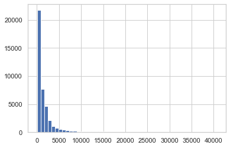

```python
# Check distribution of number of tokens per filing.
# The documents with 10K contain lots of duplicate words.
df.text_red_len.hist(bins=50);
```

```python
# Export data
df.to_csv("{}/input/adj/target_withtextred0.01_withevents_withtarget.csv".format(base_path),
          index = False)
```

```python
# Import data
df = pd.read_csv("{}/input/adj/target_withtextred0.01_withevents_withtarget.csv".format(base_path))

df_tr = df.loc[df["data_type"] == "training"]
labels = ['lg_dec', 'sm_dec', 'same', 'sm_inc', 'lg_inc']

# Fetch data
X_tr = df_tr.text_red
y_tr = df_tr.Y_disc_5

# Free memory
del [df, df_tr]
gc.collect();
```

```python
%%time

# Define, train, predict and evaluate with hyperparameter tuning
params = {'TfidfVectorizer__ngram_range': [(3, 3), (2, 2), (1, 1),
                                           (1, 3), (1, 2)]}
steps = [('TfidfVectorizer', TfidfVectorizer(max_df = 0.9, min_df = 0.01)),
         ('CatBoostClassifier', CatBoostClassifier(loss_function = 'MultiClass',
                                              task_type = "GPU", verbose = False))]
model = Pipeline(steps)
model_cv = GridSearchCV(model, params, cv = 3, verbose = True)
model_cv.fit(X_tr, y_tr)
```

```
Fitting 3 folds for each of 5 candidates, totalling 15 fits
```

```
[Parallel(n_jobs=1)]: Using backend SequentialBackend with 1 concurrent workers.
[Parallel(n_jobs=1)]: Done  15 out of  15 | elapsed: 64.5min finished
```

```
CPU times: user 57min 8s, sys: 24min 25s, total: 1h 21min 33s
Wall time: 1h 5min 22s
```

```python
print("Best parameters:")
params = model_cv.best_params_
print(params)
```

```
Best parameters:
{'TfidfVectorizer__ngram_range': (1, 1)}
```

## 8.5 Grid Search: CatBoost Hyperparameters

```python
# Import Data
zf = zipfile.ZipFile("{}/input.zip".format(base_path))
df = pd.read_csv(zf.open('target_withtext_withevents_withtarget.csv'))
df_tr = df.loc[df["data_type"] == "training"]
X_tr = df_tr.text
y_tr = df_tr.Y_disc_5

labels = ['lg_dec', 'sm_dec', 'same', 'sm_inc', 'lg_inc']

# Free memory
del [df, zf, df_tr]
gc.collect();

# Vectorize the text data
vectorizer = TfidfVectorizer(max_df = 0.9, min_df = 0.001).fit(X_tr)
X_tr = vectorizer.transform(X_tr)
X_tr = X_tr.toarray()
```

```python
%%time
model = CatBoostClassifier(loss_function = 'MultiClass',
                           task_type = "GPU", verbose = False)

# https://catboost.ai/docs/concepts/parameter-tuning.html
grid = {'learning_rate':[0.015, 0.02, 0.025, 0.03, 0.035],
        'depth':[5, 6, 7, 8, 9],
        'iterations':[750, 800, 850, 900, 950]}

grid_search_result = model.randomized_search(grid,
                                              X=X_tr,
                                              y=y_tr,
                                              cv=3,
                                              n_iter=15)
```

```
0:	loss: 1.5213699	best: 1.5213699 (0)	total: 2m 30s	remaining: 35m 7s
1:	loss: 1.5184875	best: 1.5184875 (1)	total: 3m 48s	remaining: 24m 46s
2:	loss: 1.5177663	best: 1.5177663 (2)	total: 5m 15s	remaining: 21m
3:	loss: 1.5162031	best: 1.5162031 (3)	total: 6m 49s	remaining: 18m 45s
4:	loss: 1.5180192	best: 1.5162031 (3)	total: 8m 45s	remaining: 17m 30s
5:	loss: 1.5173534	best: 1.5162031 (3)	total: 10m 52s	remaining: 16m 19s
6:	loss: 1.5170737	best: 1.5162031 (3)	total: 13m 6s	remaining: 14m 59s
7:	loss: 1.5166745	best: 1.5162031 (3)	total: 16m 42s	remaining: 14m 37s
8:	loss: 1.5148036	best: 1.5148036 (8)	total: 20m 14s	remaining: 13m 29s
9:	loss: 1.5147878	best: 1.5147878 (9)	total: 23m 44s	remaining: 11m 52s
10:	loss: 1.5156754	best: 1.5147878 (9)	total: 29m 5s	remaining: 10m 34s
11:	loss: 1.5136167	best: 1.5136167 (11)	total: 34m 56s	remaining: 8m 44s
12:	loss: 1.5137629	best: 1.5136167 (11)	total: 40m 46s	remaining: 6m 16s
13:	loss: 1.5184274	best: 1.5136167 (11)	total: 47m 12s	remaining: 3m 22s
14:	loss: 1.5161639	best: 1.5136167 (11)	total: 56m 48s	remaining: 0us
Estimating final quality...
CPU times: user 1h 11min 59s, sys: 44min 52s, total: 1h 56min 52s
Wall time: 1h 25min 19s
```

```python
# Show best parameters
grid_search_result["params"]
```

```
{'depth': 8, 'iterations': 900, 'learning_rate': 0.03}
```

## 8.6 Best Model

```python
# Import Data
zf = zipfile.ZipFile("{}/input.zip".format(base_path))
df = pd.read_csv(zf.open('target_withtext_withevents_withtarget.csv'))
df_tr = df.loc[df["data_type"] == "training"]
df_va = df.loc[df["data_type"] == "validation"]
labels = ['lg_dec', 'sm_dec', 'same', 'sm_inc', 'lg_inc']

# Check dimensions
print(df.shape)
print(df_va.shape)
print(df_tr.shape)

# Fetch data
X_tr = df_tr.text
y_tr = df_tr.Y_disc_5
X_va = df_va.text
y_va = df_va.Y_disc_5

# Vectorize the text data
vectorizer = TfidfVectorizer(max_df = 0.9, min_df = 0.001).fit(X_tr)
X_va = vectorizer.transform(X_va)
X_tr = vectorizer.transform(X_tr)
X_va = X_va.toarray()
X_tr = X_tr.toarray()
print("Dimension X_tr: {}".format(X_tr.shape))
print("Dimension X_va: {}".format(X_va.shape))

# Fit model
model = CatBoostClassifier(loss_function = 'MultiClass',
                           task_type = "GPU", verbose = 100,
                           depth = 8, iterations = 900, learning_rate = 0.03)
model.fit(X_tr, y_tr)

# Evaluation on train data
data = Pool(X_tr, y_tr)
pred = model.predict(data).flatten()
evaluate(y_tr, pred, labels)

# Evaluation on test data
data = Pool(X_va, y_va)
pred = model.predict(data).flatten()
evaluate(y_va, pred, labels)
```

```
(41763, 97)
(6756, 97)
(27032, 97)
Dimension X_tr: (27032, 15898)
Dimension X_va: (6756, 15898)
0:	learn: 1.6057796	total: 539ms	remaining: 8m 4s
100:	learn: 1.4914586	total: 47s	remaining: 6m 11s
200:	learn: 1.4589838	total: 1m 26s	remaining: 5m
300:	learn: 1.4323705	total: 2m 5s	remaining: 4m 9s
400:	learn: 1.4093343	total: 2m 42s	remaining: 3m 22s
500:	learn: 1.3886362	total: 3m 19s	remaining: 2m 38s
600:	learn: 1.3671691	total: 3m 56s	remaining: 1m 57s
700:	learn: 1.3487869	total: 4m 32s	remaining: 1m 17s
800:	learn: 1.3320866	total: 5m 8s	remaining: 38.1s
899:	learn: 1.3151256	total: 5m 44s	remaining: 0us

Confusion matrix (absolute):
```

|  |  | Predicted lg_dec | Predicted sm_dec | Predicted same | Predicted sm_inc | Predicted lg_inc |
| --- | --- | --- | --- | --- | --- | --- |
| True | lg_dec | 3177 | 481 | 743 | 476 | 485 |
|  | sm_dec | 462 | 3054 | 996 | 375 | 578 |
|  | same | 352 | 280 | 3944 | 351 | 469 |
|  | sm_inc | 379 | 354 | 1011 | 3057 | 630 |
|  | lg_inc | 295 | 447 | 718 | 490 | 3428 |

```
Confusion matrix (relative):
```

|  |  | Predicted lg_dec | Predicted sm_dec | Predicted same | Predicted sm_inc | Predicted lg_inc |
| --- | --- | --- | --- | --- | --- | --- |
| True | lg_dec | 11.75 | 1.78 | 2.75 | 1.76 | 1.79 |
|  | sm_dec | 1.71 | 11.30 | 3.68 | 1.39 | 2.14 |
|  | same | 1.30 | 1.04 | 14.59 | 1.30 | 1.73 |
|  | sm_inc | 1.40 | 1.31 | 3.74 | 11.31 | 2.33 |
|  | lg_inc | 1.09 | 1.65 | 2.66 | 1.81 | 12.68 |

```
Classification report:

              precision    recall  f1-score   support

      lg_dec       0.68      0.59      0.63      5362
      lg_inc       0.61      0.64      0.63      5378
        same       0.53      0.73      0.62      5396
      sm_dec       0.66      0.56      0.61      5465
      sm_inc       0.64      0.56      0.60      5431

    accuracy                           0.62     27032
   macro avg       0.63      0.62      0.62     27032
weighted avg       0.63      0.62      0.62     27032

Overall accuracy: 0.6163
Overall f1_score: 0.6162

Confusion matrix (absolute):
```

|  |  | Predicted lg_dec | Predicted sm_dec | Predicted same | Predicted sm_inc | Predicted lg_inc |
| --- | --- | --- | --- | --- | --- | --- |
| True | lg_dec | 399 | 162 | 204 | 176 | 412 |
|  | sm_dec | 168 | 271 | 480 | 249 | 170 |
|  | same | 90 | 263 | 567 | 277 | 134 |
|  | sm_inc | 155 | 261 | 481 | 290 | 176 |
|  | lg_inc | 325 | 148 | 206 | 156 | 536 |

```
Confusion matrix (relative):
```

|  |  | Predicted lg_dec | Predicted sm_dec | Predicted same | Predicted sm_inc | Predicted lg_inc |
| --- | --- | --- | --- | --- | --- | --- |
| True | lg_dec | 5.91 | 2.40 | 3.02 | 2.61 | 6.10 |
|  | sm_dec | 2.49 | 4.01 | 7.10 | 3.69 | 2.52 |
|  | same | 1.33 | 3.89 | 8.39 | 4.10 | 1.98 |
|  | sm_inc | 2.29 | 3.86 | 7.12 | 4.29 | 2.61 |
|  | lg_inc | 4.81 | 2.19 | 3.05 | 2.31 | 7.93 |

```
Classification report:

              precision    recall  f1-score   support

      lg_dec       0.35      0.29      0.32      1353
      lg_inc       0.38      0.39      0.38      1371
        same       0.29      0.43      0.35      1331
      sm_dec       0.25      0.20      0.22      1338
      sm_inc       0.25      0.21      0.23      1363

    accuracy                           0.31      6756
   macro avg       0.30      0.31      0.30      6756
weighted avg       0.30      0.31      0.30      6756

Overall accuracy: 0.3054
Overall f1_score: 0.3008
```

# 9. LSTM with GloVe

- https://stackoverflow.com/questions/50060241/how-to-use-glove-word-embeddings-file-on-google-colaboratory
- https://keras.io/examples/pretrained_word_embeddings/
- https://keras.io/visualization/

Import GloVe embedding indices and save them as pickle (one time operation).

```python
#!wget http://nlp.stanford.edu/data/glove.6B.zip
```

```python
# zip_ref = zipfile.ZipFile("/content/glove.6B.zip", 'r')
# zip_ref.extractall("/content/glove.6B")
# zip_ref.close()

# print('Indexing word vectors.')
# GLOVE_DIR = "/content/glove.6B"
# embeddings_index = {}
# with open(os.path.join(GLOVE_DIR, 'glove.6B.100d.txt')) as f:
#     for line in f:
#         word, coefs = line.split(maxsplit=1)
#         coefs = np.fromstring(coefs, 'f', sep=' ')
#         embeddings_index[word] = coefs

# print('Found %s word vectors.' % len(embeddings_index))

# pickle.dump({'embeddings_index' : embeddings_index},
#             open('{}/GloVe.pkl'.format(base_path), 'wb'))
```

[output not shown]

```python
from sklearn.preprocessing import LabelEncoder
from keras.models import Model
from keras.layers import LSTM, Activation, Dense, Dropout, Input, Embedding
from keras.optimizers import RMSprop
from keras.preprocessing.text import Tokenizer
from keras.preprocessing import sequence
from keras.utils import to_categorical
from keras.callbacks import EarlyStopping
from keras.preprocessing.sequence import pad_sequences
from keras.utils import to_categorical
from keras.initializers import Constant
from keras.utils import plot_model

from keras import backend as K
print(K.tensorflow_backend._get_available_gpus())
import tensorflow as tf
print(tf.test.gpu_device_name())

BASE_DIR = base_path
MAX_SEQUENCE_LENGTH = 10000
MAX_NUM_WORDS = 10000
EMBEDDING_DIM = 100
VALIDATION_SPLIT = 0.2


# Import GloVe indexing
with open('{}/GloVe.pkl'.format(base_path), "rb") as f:
    data = pickle.load(f)
    embeddings_index = data["embeddings_index"]
```

```python
# Import Data
zf = zipfile.ZipFile("{}/input.zip".format(base_path))
df = pd.read_csv(zf.open('target_withraw_withevents_withtarget.csv'))
df_tr = df.loc[df["data_type"] == "training"]
df_va = df.loc[df["data_type"] == "validation"]

labels = ['lg_dec', 'sm_dec', 'same', 'sm_inc', 'lg_inc']
print(df.shape)
print(df_va.shape)
print(df_tr.shape)

X_tr = df_tr.raw
y_tr = df_tr.Y_disc_5
X_va = df_va.raw
y_va = df_va.Y_disc_5
```

```
(41763, 97)
(6756, 97)
(27032, 97)
```

```python
# Removing numeric elements
X_va  = X_va.str.replace('\d+', '')
X_tr  = X_tr.str.replace('\d+', '')
```

```python
# Vectorize the text samples into a 2D integer tensor
print('Processing text dataset')
tokenizer = Tokenizer(num_words=MAX_NUM_WORDS)
tokenizer.fit_on_texts(X_tr)

X_tr = tokenizer.texts_to_sequences(X_tr)
X_tr = pad_sequences(X_tr, maxlen=MAX_SEQUENCE_LENGTH)

X_va = tokenizer.texts_to_sequences(X_va)
X_va = pad_sequences(X_va, maxlen=MAX_SEQUENCE_LENGTH)
```

```
Processing text dataset
```

```python
# Convert class to int and then to class matrix
le = LabelEncoder().fit(y_tr)
y_tr = le.transform(y_tr).reshape(-1,1)
y_va = le.transform(y_va).reshape(-1,1)

y_tr = to_categorical(np.asarray(y_tr))
y_va = to_categorical(np.asarray(y_va))
```

```python
# Check shapes
print('Shape X_tr:', X_tr.shape)
print('Shape X_va:', X_va.shape)

print('Shape y_tr:', y_tr.shape)
print('Shape y_va:', y_va.shape)
```

```
Shape X_tr: (27032, 10000)
Shape X_va: (6756, 10000)
Shape y_tr: (27032, 5)
Shape y_va: (6756, 5)
```

```python
print('Preparing embedding matrix.')

# prepare embedding matrix
word_index = tokenizer.word_index
num_words = min(MAX_NUM_WORDS, len(word_index) + 1)
embedding_matrix = np.zeros((num_words, EMBEDDING_DIM))
for word, i in word_index.items():
    if i >= MAX_NUM_WORDS:
        continue
    embedding_vector = embeddings_index.get(word)
    if embedding_vector is not None:
        # words not found in embedding index will be all-zeros.
        embedding_matrix[i] = embedding_vector

print("Shape embedding_matrix: {}".format(embedding_matrix.shape))
```

```
Preparing embedding matrix.
Shape embedding_matrix: (10000, 100)
```

```python
# load pre-trained word embeddings into an Embedding layer
# note that we set trainable = False so as to keep the embeddings fixed
embedding_layer = Embedding(input_dim=num_words,
                            output_dim=EMBEDDING_DIM,
                            embeddings_initializer=Constant(embedding_matrix),
                            input_length=MAX_SEQUENCE_LENGTH,
                            trainable = True)
```

```
WARNING:tensorflow:From /usr/local/lib/python3.6/dist-packages/keras/backend/tensorflow_backend.py:66: The name tf.get_default_graph is deprecated. Please use tf.compat.v1.get_default_graph instead.
```

## Training LSTM

```python
def RNN():
    inputs = Input(shape=(MAX_SEQUENCE_LENGTH,), dtype='int32')
    layer = embedding_layer(inputs)
    layer = LSTM(128)(layer)
    layer = Dense(256,activation='relu')(layer)
    layer = Dropout(0.5)(layer)
    layer = Dense(5,activation='softmax')(layer)
    model = Model(inputs=inputs,outputs=layer)
    return model

model = RNN()
model.summary()
model.compile(loss='categorical_crossentropy',optimizer='adam',metrics=['accuracy'])
```

[output not shown]

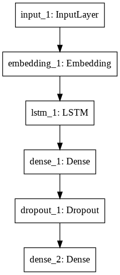

```python
plot_model(model, to_file='{}/figures/model.png'.format(base_path), show_shapes=True)
```

```python
history = model.fit(X_tr,y_tr,batch_size=128,epochs=10,
          validation_split=0.2, callbacks=[EarlyStopping(monitor='val_acc',
                                          min_delta=0.001, patience=3)])
```

[output not shown]

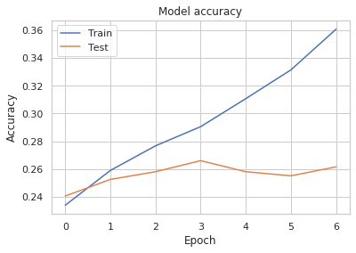

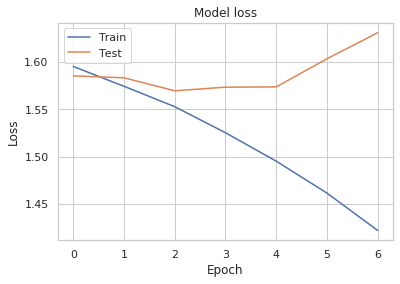

```python
# Plot training & validation accuracy values
plt.plot(history.history['acc'])
plt.plot(history.history['val_acc'])
plt.title('Model accuracy')
plt.ylabel('Accuracy')
plt.xlabel('Epoch')
plt.legend(['Train', 'Test'], loc='upper left')
plt.show()

# Plot training & validation loss values
plt.plot(history.history['loss'])
plt.plot(history.history['val_loss'])
plt.title('Model loss')
plt.ylabel('Loss')
plt.xlabel('Epoch')
plt.legend(['Train', 'Test'], loc='upper left')
plt.show()
```

```python
# Save model
# model.save('{}/lstm1_fnn1_acc.h5'.format(base_path)) # https://keras.io/getting-started/faq/#how-can-i-save-a-keras-model

# Load model
from keras.models import load_model
model = load_model('{}/lstm1_fnn1_acc.h5'.format(base_path))
```

[output not shown]

```python
# Evaluate on training data
pred = model.predict(X_tr)
pred_inv = le.inverse_transform(np.argmax(pred, axis = 1))
y_tr_inv = le.inverse_transform(np.argmax(y_tr, axis = 1))
evaluate(y_tr_inv, pred_inv, labels)
```

```
Confusion matrix (absolute):
```

|  |  | Predicted lg_dec | Predicted sm_dec | Predicted same | Predicted sm_inc | Predicted lg_inc |
| --- | --- | --- | --- | --- | --- | --- |
| True | lg_dec | 1772 | 322 | 230 | 658 | 2380 |
|  | sm_dec | 621 | 1231 | 971 | 1643 | 999 |
|  | same | 529 | 747 | 1642 | 1718 | 760 |
|  | sm_inc | 687 | 721 | 825 | 2195 | 1003 |
|  | lg_inc | 1097 | 323 | 202 | 598 | 3158 |

```
Confusion matrix (relative):
```

|  |  | Predicted lg_dec | Predicted sm_dec | Predicted same | Predicted sm_inc | Predicted lg_inc |
| --- | --- | --- | --- | --- | --- | --- |
| True | lg_dec | 6.56 | 1.19 | 0.85 | 2.43 | 8.80 |
|  | sm_dec | 2.30 | 4.55 | 3.59 | 6.08 | 3.70 |
|  | same | 1.96 | 2.76 | 6.07 | 6.36 | 2.81 |
|  | sm_inc | 2.54 | 2.67 | 3.05 | 8.12 | 3.71 |
|  | lg_inc | 4.06 | 1.19 | 0.75 | 2.21 | 11.68 |

```
Classification report:

              precision    recall  f1-score   support

      lg_dec       0.38      0.33      0.35      5362
      lg_inc       0.38      0.59      0.46      5378
        same       0.42      0.30      0.35      5396
      sm_dec       0.37      0.23      0.28      5465
      sm_inc       0.32      0.40      0.36      5431

    accuracy                           0.37     27032
   macro avg       0.37      0.37      0.36     27032
weighted avg       0.37      0.37      0.36     27032

Overall accuracy: 0.3699
Overall f1_score: 0.361
```

```python
# Evaluate on validation data
pred = model.predict(X_va)
pred_inv = le.inverse_transform(np.argmax(pred, axis = 1))
y_va_inv = le.inverse_transform(np.argmax(y_va, axis = 1))
evaluate(y_va_inv, pred_inv, labels)
```

```
Confusion matrix (absolute):
```

|  |  | Predicted lg_dec | Predicted sm_dec | Predicted same | Predicted sm_inc | Predicted lg_inc |
| --- | --- | --- | --- | --- | --- | --- |
| True | lg_dec | 338 | 132 | 95 | 229 | 559 |
|  | sm_dec | 220 | 204 | 213 | 406 | 295 |
|  | same | 173 | 219 | 234 | 464 | 241 |
|  | sm_inc | 198 | 181 | 246 | 408 | 330 |
|  | lg_inc | 282 | 112 | 115 | 237 | 625 |

```
Confusion matrix (relative):
```

|  |  | Predicted lg_dec | Predicted sm_dec | Predicted same | Predicted sm_inc | Predicted lg_inc |
| --- | --- | --- | --- | --- | --- | --- |
| True | lg_dec | 5.00 | 1.95 | 1.41 | 3.39 | 8.27 |
|  | sm_dec | 3.26 | 3.02 | 3.15 | 6.01 | 4.37 |
|  | same | 2.56 | 3.24 | 3.46 | 6.87 | 3.57 |
|  | sm_inc | 2.93 | 2.68 | 3.64 | 6.04 | 4.88 |
|  | lg_inc | 4.17 | 1.66 | 1.70 | 3.51 | 9.25 |

```
Classification report:

              precision    recall  f1-score   support

      lg_dec       0.28      0.25      0.26      1353
      lg_inc       0.30      0.46      0.37      1371
        same       0.26      0.18      0.21      1331
      sm_dec       0.24      0.15      0.19      1338
      sm_inc       0.23      0.30      0.26      1363

    accuracy                           0.27      6756
   macro avg       0.26      0.27      0.26      6756
weighted avg       0.26      0.27      0.26      6756

Overall accuracy: 0.2678
Overall f1_score: 0.2582
```

# 10. Best Model Evaluation

First, the best model is trained on validation and training data and evaluated on the test data.

```python
# Import Data
zf = zipfile.ZipFile("{}/input.zip".format(base_path))
df = pd.read_csv(zf.open('target_withtext_withevents_withtarget.csv'))
df_tr = df.loc[df["data_type"] == "training"]
df_va = df.loc[df["data_type"] == "validation"]
df_tr = df_tr.append(df_va)
df_te = df.loc[df["data_type"] == "test"]
labels = ['lg_dec', 'sm_dec', 'same', 'sm_inc', 'lg_inc']

# Check dimensions
print(df.shape)
print(df_tr.shape)
print(df_te.shape)

# Fetch data
X_tr = df_tr.text
y_tr = df_tr.Y_disc_5
X_te = df_te.text
y_te = df_te.Y_disc_5

# Vectorize the text data
vectorizer = TfidfVectorizer(max_df = 0.9, min_df = 0.001).fit(X_tr)
X_te = vectorizer.transform(X_te)
X_tr = vectorizer.transform(X_tr)
X_te = X_te.toarray()
X_tr = X_tr.toarray()
print("Dimension X_tr: {}".format(X_tr.shape))
print("Dimension X_te: {}".format(X_te.shape))
```

```
(41763, 97)
(33788, 97)
(7975, 97)
Dimension X_tr: (33788, 16090)
Dimension X_te: (7975, 16090)
```

```python
# Fit model
model = CatBoostClassifier(loss_function = 'MultiClass',
                           task_type = "GPU", verbose = 100,
                           depth = 8, iterations = 900, learning_rate = 0.03)
model.fit(X_tr, y_tr)
```

```
0:	learn: 1.6058101	total: 526ms	remaining: 7m 53s
100:	learn: 1.4941562	total: 51.6s	remaining: 6m 48s
200:	learn: 1.4636401	total: 1m 35s	remaining: 5m 32s
300:	learn: 1.4422918	total: 2m 16s	remaining: 4m 32s
400:	learn: 1.4219774	total: 2m 57s	remaining: 3m 41s
500:	learn: 1.4032033	total: 3m 38s	remaining: 2m 53s
600:	learn: 1.3858664	total: 4m 18s	remaining: 2m 8s
700:	learn: 1.3709968	total: 4m 57s	remaining: 1m 24s
800:	learn: 1.3562115	total: 5m 36s	remaining: 41.6s
899:	learn: 1.3419106	total: 6m 15s	remaining: 0us
```

```
<catboost.core.CatBoostClassifier at 0x7f63ffa42470>
```

```python
# Export model
#model.save_model("{}/best_model".format(base_path))

# Import model
best_model = CatBoostClassifier()
best_model.load_model("{}/best_model".format(base_path))

# Evaluation on train data
data = Pool(X_tr, y_tr)
pred = best_model.predict(data).flatten()
evaluate(y_tr, pred, labels)

# Evaluation on test data
data = Pool(X_te, y_te)
pred = best_model.predict(data).flatten()
res = evaluate(y_te, pred, labels, return_data = True)
```

```
Confusion matrix (absolute):
```

|  |  | Predicted lg_dec | Predicted sm_dec | Predicted same | Predicted sm_inc | Predicted lg_inc |
| --- | --- | --- | --- | --- | --- | --- |
| True | lg_dec | 3777 | 605 | 956 | 641 | 736 |
|  | sm_dec | 621 | 3382 | 1511 | 541 | 748 |
|  | same | 445 | 443 | 4681 | 545 | 613 |
|  | sm_inc | 538 | 501 | 1428 | 3532 | 795 |
|  | lg_inc | 494 | 579 | 923 | 643 | 4110 |

```
Confusion matrix (relative):
```

|  |  | Predicted lg_dec | Predicted sm_dec | Predicted same | Predicted sm_inc | Predicted lg_inc |
| --- | --- | --- | --- | --- | --- | --- |
| True | lg_dec | 11.18 | 1.79 | 2.83 | 1.90 | 2.18 |
|  | sm_dec | 1.84 | 10.01 | 4.47 | 1.60 | 2.21 |
|  | same | 1.32 | 1.31 | 13.85 | 1.61 | 1.81 |
|  | sm_inc | 1.59 | 1.48 | 4.23 | 10.45 | 2.35 |
|  | lg_inc | 1.46 | 1.71 | 2.73 | 1.90 | 12.16 |

```
Classification report:

              precision    recall  f1-score   support

      lg_dec       0.64      0.56      0.60      6715
      lg_inc       0.59      0.61      0.60      6749
        same       0.49      0.70      0.58      6727
      sm_dec       0.61      0.50      0.55      6803
      sm_inc       0.60      0.52      0.56      6794

    accuracy                           0.58     33788
   macro avg       0.59      0.58      0.58     33788
weighted avg       0.59      0.58      0.58     33788

Overall accuracy: 0.5766
Overall f1_score: 0.576

Confusion matrix (absolute):
```

|  |  | Predicted lg_dec | Predicted sm_dec | Predicted same | Predicted sm_inc | Predicted lg_inc |
| --- | --- | --- | --- | --- | --- | --- |
| True | lg_dec | 496 | 248 | 235 | 226 | 435 |
|  | sm_dec | 200 | 281 | 542 | 340 | 220 |
|  | same | 136 | 293 | 688 | 357 | 161 |
|  | sm_inc | 200 | 258 | 513 | 335 | 218 |
|  | lg_inc | 409 | 187 | 204 | 200 | 593 |

```
Confusion matrix (relative):
```

|  |  | Predicted lg_dec | Predicted sm_dec | Predicted same | Predicted sm_inc | Predicted lg_inc |
| --- | --- | --- | --- | --- | --- | --- |
| True | lg_dec | 6.22 | 3.11 | 2.95 | 2.83 | 5.45 |
|  | sm_dec | 2.51 | 3.52 | 6.80 | 4.26 | 2.76 |
|  | same | 1.71 | 3.67 | 8.63 | 4.48 | 2.02 |
|  | sm_inc | 2.51 | 3.24 | 6.43 | 4.20 | 2.73 |
|  | lg_inc | 5.13 | 2.34 | 2.56 | 2.51 | 7.44 |

```
Classification report:

              precision    recall  f1-score   support

      lg_dec       0.34      0.30      0.32      1640
      lg_inc       0.36      0.37      0.37      1593
        same       0.32      0.42      0.36      1635
      sm_dec       0.22      0.18      0.20      1583
      sm_inc       0.23      0.22      0.22      1524

    accuracy                           0.30      7975
   macro avg       0.30      0.30      0.29      7975
weighted avg       0.30      0.30      0.30      7975

Overall accuracy: 0.3001
Overall f1_score: 0.2958
```

```python
# Print confusion matrix for latex
cm_abs = res["cm_abs"]
print(cm_abs.to_latex())
```

```
\begin{tabular}{llrrrrr}
\toprule
     &        & \multicolumn{5}{l}{Predicted} \\
     &        &    lg\_dec & sm\_dec & same & sm\_inc & lg\_inc \\
{} & {} &           &        &      &        &        \\
\midrule
True & lg\_dec &       496 &    248 &  235 &    226 &    435 \\
     & sm\_dec &       200 &    281 &  542 &    340 &    220 \\
     & same &       136 &    293 &  688 &    357 &    161 \\
     & sm\_inc &       200 &    258 &  513 &    335 &    218 \\
     & lg\_inc &       409 &    187 &  204 &    200 &    593 \\
\bottomrule
\end{tabular}
```

## 10.1 Model Performance in Relation to SIC Domain, Business Location, 8K-event, Ticker Symbol

- The *first* plot shows the distribution of the counts for wrong and correct classifications (separately) across the levels of the categorical variable (in percentages). This means that the sum of all percentage values for `correct_classification` adds to 100 percent and that the sum of all percentage values for `wrong_classification` adds to 100 percent. In other words, we compare two distributions.
- The *second* plot shows the total (absolute) number of correct and wrong classifications per level of the categorical variable. In some cases, we don't notice a strong difference between correct and false classifications in the first plot but we do in the second plot.

In practice, the second plot is what we might care about the most. This is because we would, in practice make a classification for e.g. an 8K-filing corresponding to a specific 8K-event or a specic SIC domain or a specific business location. Hence, we are interested in the past performance of the model for this specific categorical level, and would therefore like to know the number of correct and wrong classifications for this level for the test data.

## 10.1.1 All test data

First, the plots are created using all observations in the test data, no matter what classification was done for these observations. Note that these visualizations may give you an overly pessimistic view of the model. The visualizations include cases in which we would not actually conduct any trades. As of right now, we might only consider any trades when the model classified a large increase (`lg_inc`). Hence, in section 10.1.2 these classifications are analyzed in more detail.

```python
# Add predictions to test data
df_te.loc[:, "pred"] = pred
```

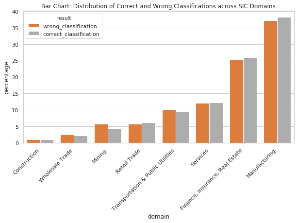

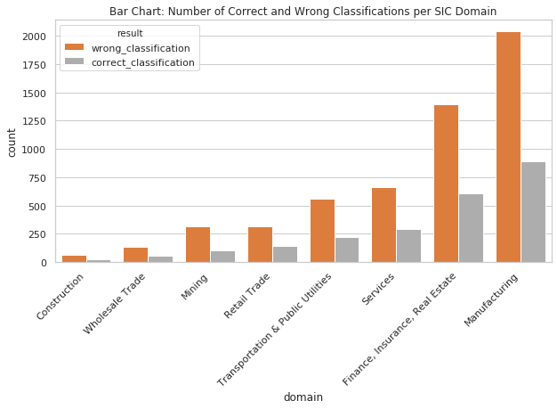

```python
sns.set_style("whitegrid")

# Visualize wrong and correct classifications by domain
df_sub = df_te
colors = {'correct_classification': sns.color_palette("Greys").as_hex()[2],
          'wrong_classification': sns.color_palette("Oranges").as_hex()[3]}

df_sub.loc[df_sub["Y_disc_5"] != df_sub["pred"], "result"] = "wrong_classification"
df_sub.loc[df_sub["Y_disc_5"] == df_sub["pred"], "result"] = "correct_classification"
df_sub = df_sub.groupby(["result", "domain"]).size().groupby(level=0).apply(lambda x: 100 * x / float(x.sum()))\
               .reset_index().rename(columns = {0: "percentage"}).sort_values(["percentage", "result"])

plt.rcParams["figure.figsize"] = [10,5]
p = sns.barplot(x = "domain", y = "percentage", data = df_sub, hue = "result", palette = colors,
                hue_order = ["wrong_classification", "correct_classification"])
p.set_xticklabels(p.get_xticklabels(), rotation = 45, horizontalalignment='right')
plt.title("Bar Chart: Distribution of Correct and Wrong Classifications across SIC Domains")
plt.show(p)

df_sub = df_te
df_sub.loc[df_sub["Y_disc_5"] != df_sub["pred"], "result"] = "wrong_classification"
df_sub.loc[df_sub["Y_disc_5"] == df_sub["pred"], "result"] = "correct_classification"
df_sub = df_sub.groupby(["result", "domain"]).size().reset_index().rename(columns = {0: "count"})\
               .sort_values(["count", "result"])

plt.rcParams["figure.figsize"] = [10,5]
p = sns.barplot(x = "domain", y = "count", data = df_sub, hue = "result", palette = colors,
                 hue_order = ["wrong_classification", "correct_classification"])
p.set_xticklabels(p.get_xticklabels(), rotation = 45, horizontalalignment='right')
plt.title("Bar Chart: Number of Correct and Wrong Classifications per SIC Domain")
plt.show(p)
```

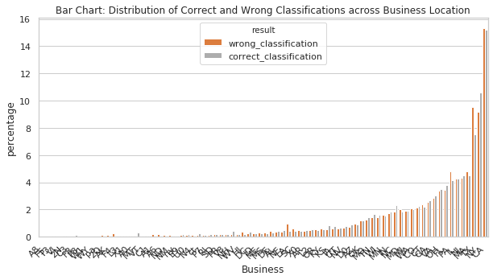

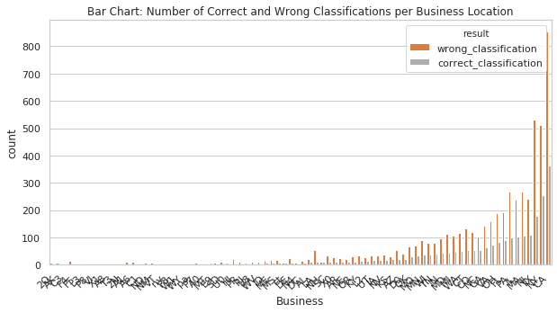

```python
sns.set_style("whitegrid")

# Visualize wrong and correct classifications by business location
df_sub = df_te
colors = {'correct_classification': sns.color_palette("Greys").as_hex()[2],
          'wrong_classification': sns.color_palette("Oranges").as_hex()[3]}

df_sub.loc[df_sub["Y_disc_5"] != df_sub["pred"], "result"] = "wrong_classification"
df_sub.loc[df_sub["Y_disc_5"] == df_sub["pred"], "result"] = "correct_classification"
df_sub = df_sub.groupby(["result", "Business"]).size().groupby(level=0).apply(lambda x: 100 * x / float(x.sum()))\
               .reset_index().rename(columns = {0: "percentage"}).sort_values(["percentage", "result"])

plt.rcParams["figure.figsize"] = [10,5]
p = sns.barplot(x = "Business", y = "percentage", data = df_sub, hue = "result", palette = colors,
                 hue_order = ["wrong_classification", "correct_classification"])
p.set_xticklabels(p.get_xticklabels(), rotation = 45, horizontalalignment='right')
plt.title("Bar Chart: Distribution of Correct and Wrong Classifications across Business Location")
plt.show(p)

df_sub = df_te
df_sub.loc[df_sub["Y_disc_5"] != df_sub["pred"], "result"] = "wrong_classification"
df_sub.loc[df_sub["Y_disc_5"] == df_sub["pred"], "result"] = "correct_classification"
df_sub = df_sub.groupby(["result", "Business"]).size().reset_index().rename(columns = {0: "count"}).\
        sort_values(["count", "result"])

plt.rcParams["figure.figsize"] = [10,5]
p = sns.barplot(x = "Business", y = "count", data = df_sub, hue = "result", palette = colors,
                 hue_order = ["wrong_classification", "correct_classification"])
p.set_xticklabels(p.get_xticklabels(), rotation = 45, horizontalalignment='right')
plt.title("Bar Chart: Number of Correct and Wrong Classifications per Business Location")
plt.show(p)
```

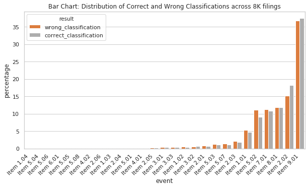

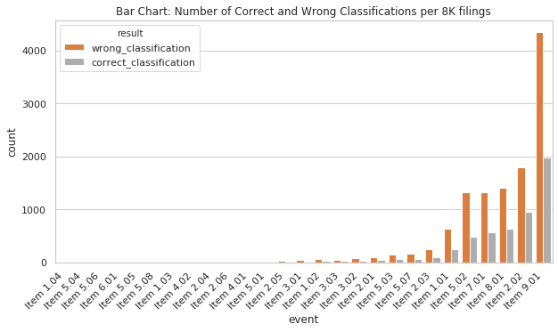

```python
sns.set_style("whitegrid")

# Visualize wrong and correct classifications by 8K filing
df_sub = df_te
colors = {'correct_classification': sns.color_palette("Greys").as_hex()[2],
          'wrong_classification': sns.color_palette("Oranges").as_hex()[3]}

df_sub = df_sub.loc[:, df_sub.columns.str.startswith(("Item", "result"))].groupby(["result"]).sum()
df_sub = df_sub.assign(counter = df_sub.index.tolist()).melt('counter').\
                rename(columns = {'counter': 'result', 'variable': 'event', 'value': 'count'})\
                .groupby(['result', 'event']).sum().groupby(level=0).apply(lambda x: 100 * x / float(x.sum()))\
                .reset_index().rename(columns = {"count": "percentage"}).sort_values(["percentage", "result"])

plt.rcParams["figure.figsize"] = [10,5]
p = sns.barplot(x = "event", y = "percentage", data = df_sub, hue = "result", palette = colors,
                 hue_order = ["wrong_classification", "correct_classification"])
p.set_xticklabels(p.get_xticklabels(), rotation = 45, horizontalalignment='right')
plt.title("Bar Chart: Distribution of Correct and Wrong Classifications across 8K filings")
plt.show(p)

df_sub = df_te
df_sub = df_sub.loc[:, df_sub.columns.str.startswith(("Item", "result"))].groupby(["result"]).sum()
df_sub = df_sub.assign(counter = df_sub.index.tolist()).melt('counter').\
                rename(columns = {'counter': 'result', 'variable': 'event', 'value': 'count'}).sort_values("count")

plt.rcParams["figure.figsize"] = [10,5]
p = sns.barplot(x = "event", y = "count", data = df_sub, hue = "result", palette = colors,
                 hue_order = ["wrong_classification", "correct_classification"])
p.set_xticklabels(p.get_xticklabels(), rotation = 45, horizontalalignment='right')
plt.title("Bar Chart: Number of Correct and Wrong Classifications per 8K filings")
plt.show(p)
```

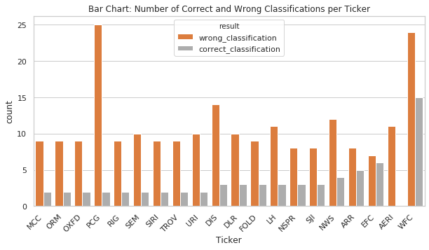

```python
sns.set_style("whitegrid")

# Visualize wrong and correct classifications by Ticker (only tickers with >= 10 filings)

df_temp = df_te.groupby("Ticker").size().reset_index().rename(columns = {0: "cnt"})
df_temp = df_temp.loc[df_temp["cnt"] > 10, :]
df_merged = pd.merge(df_te, df_temp, on = "Ticker", how = "right")

df_sub = df_merged
df_sub.loc[df_sub["Y_disc_5"] != df_sub["pred"], "result"] = "wrong_classification"
df_sub.loc[df_sub["Y_disc_5"] == df_sub["pred"], "result"] = "correct_classification"
df_sub = df_sub.groupby(["result", "Ticker"]).size().reset_index().rename(columns = {0: "count"}).\
        sort_values(["count", "result"])

plt.rcParams["figure.figsize"] = [10,5]
p = sns.barplot(x = "Ticker", y = "count", data = df_sub, hue = "result", palette = colors,
                hue_order = ["wrong_classification", "correct_classification"])
p.set_xticklabels(p.get_xticklabels(), rotation = 45, horizontalalignment='right')
plt.title("Bar Chart: Number of Correct and Wrong Classifications per Ticker")
plt.show(p)
```

# 10.1.2 Only test data classified as lg_inc

Here, we only consider test data observations that were classified as `lg_inc`. We can think of these test observations as cases, where we might have taken a long position because the model predicted a large increase. After taking the trade, we would have observed the actual change in the stock price: `lg_inc`, `sm_inc`, `zero` might have been acceptable for us since we would not have lost any money (or only little money in the `zero` category). `sm_dec` and in particular `lg_dec` would have given us a loss. In other words, we want to avoid the misclassifications of `sm_dec` and `lg_dec` as `lg_inc`.

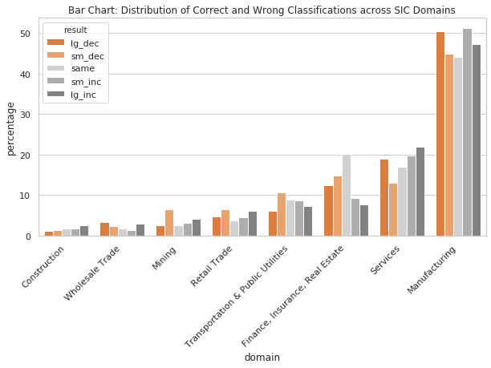

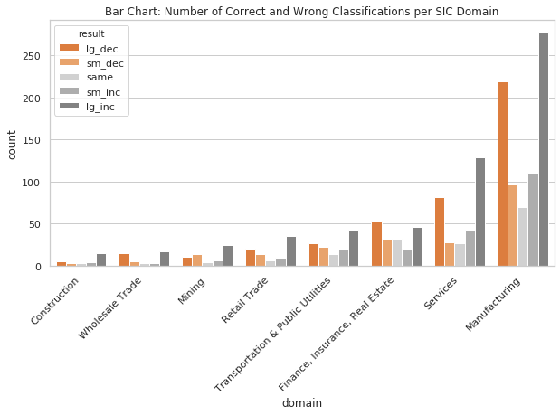

```python
# Visualize classifications by domain (only observations classified as lg_inc)
colors = {'lg_inc': sns.color_palette("Greys").as_hex()[3],
          'sm_inc': sns.color_palette("Greys").as_hex()[2],
          'same': sns.color_palette("Greys").as_hex()[1],
          'sm_dec': sns.color_palette("Oranges").as_hex()[2],
          'lg_dec': sns.color_palette("Oranges").as_hex()[3]}

df_sub = df_te
df_sub = df_sub[df_sub["pred"] == "lg_inc"]
df_sub.loc[:, "result"] = df_sub["Y_disc_5"]
df_sub = df_sub.groupby(["result", "domain"]).size().groupby(level=0).apply(lambda x: 100 * x / float(x.sum()))\
               .reset_index().rename(columns = {0: "percentage"}).sort_values(["percentage", "result"])

plt.rcParams["figure.figsize"] = [10,5]
p = sns.barplot(x = "domain", y = "percentage", data = df_sub, hue = "result", palette = colors,
                hue_order = ["lg_dec", "sm_dec", "same", "sm_inc", "lg_inc"])
p.set_xticklabels(p.get_xticklabels(), rotation = 45, horizontalalignment='right')
plt.title("Bar Chart: Distribution of Correct and Wrong Classifications across SIC Domains")
plt.show(p)

df_sub = df_te
df_sub = df_sub[df_sub["pred"] == "lg_inc"]
df_sub.loc[:, "result"] = df_sub["Y_disc_5"]
df_sub = df_sub.groupby(["result", "domain"]).size().reset_index().rename(columns = {0: "count"})\
               .sort_values(["count", "result"])

plt.rcParams["figure.figsize"] = [10,5]
p = sns.barplot(x = "domain", y = "count", data = df_sub, hue = "result", palette = colors,
                hue_order = ["lg_dec", "sm_dec", "same", "sm_inc", "lg_inc"])
p.set_xticklabels(p.get_xticklabels(), rotation = 45, horizontalalignment='right')
plt.title("Bar Chart: Number of Correct and Wrong Classifications per SIC Domain")
plt.show(p)
```

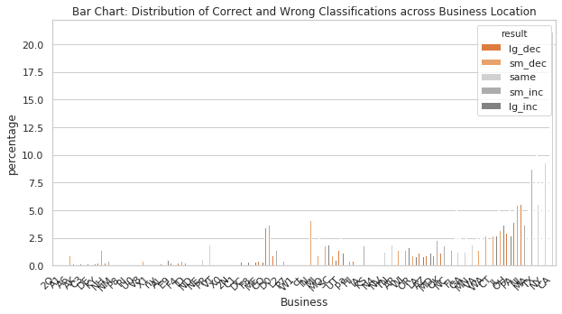

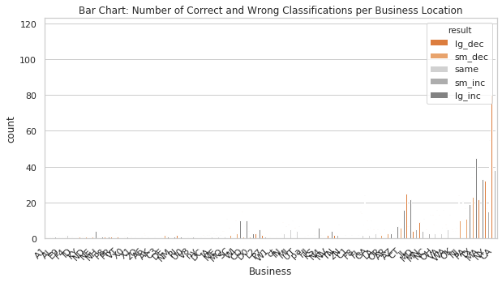

```python
sns.set_style("whitegrid")

# Visualize classifications by  business location (only observations classified as lg_inc)
colors = {'lg_inc': sns.color_palette("Greys").as_hex()[3],
          'sm_inc': sns.color_palette("Greys").as_hex()[2],
          'same': sns.color_palette("Greys").as_hex()[1],
          'sm_dec': sns.color_palette("Oranges").as_hex()[2],
          'lg_dec': sns.color_palette("Oranges").as_hex()[3]}

df_sub = df_te
df_sub = df_sub[df_sub["pred"] == "lg_inc"]
df_sub.loc[:, "result"] = df_sub["Y_disc_5"]
df_sub = df_sub.groupby(["result", "Business"]).size().groupby(level=0).apply(lambda x: 100 * x / float(x.sum()))\
               .reset_index().rename(columns = {0: "percentage"}).sort_values(["percentage", "result"])

plt.rcParams["figure.figsize"] = [10,5]
p = sns.barplot(x = "Business", y = "percentage", data = df_sub, hue = "result", palette = colors,
                hue_order = ["lg_dec", "sm_dec", "same", "sm_inc", "lg_inc"])
p.set_xticklabels(p.get_xticklabels(), rotation = 45, horizontalalignment='right')
plt.title("Bar Chart: Distribution of Correct and Wrong Classifications across Business Location")
plt.show(p)

df_sub = df_te
df_sub = df_sub[df_sub["pred"] == "lg_inc"]
df_sub.loc[:, "result"] = df_sub["Y_disc_5"]
df_sub = df_sub.groupby(["result", "Business"]).size().reset_index().rename(columns = {0: "count"}).\
        sort_values(["count", "result"])

plt.rcParams["figure.figsize"] = [10,5]
p = sns.barplot(x = "Business", y = "count", data = df_sub, hue = "result", palette = colors,
                hue_order = ["lg_dec", "sm_dec", "same", "sm_inc", "lg_inc"])
p.set_xticklabels(p.get_xticklabels(), rotation = 45, horizontalalignment='right')
plt.title("Bar Chart: Number of Correct and Wrong Classifications per Business Location")
plt.show(p)
```

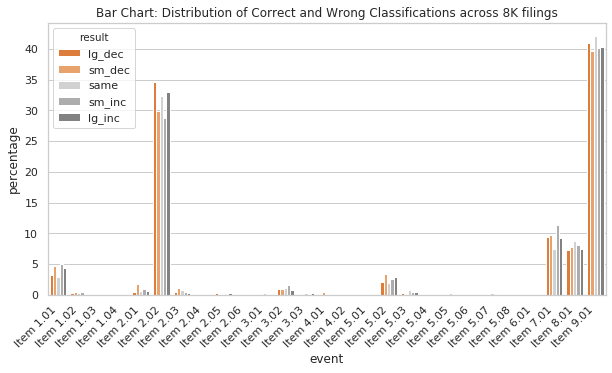

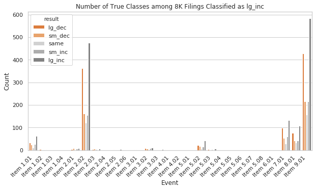

```python
sns.set_style("whitegrid")

# Visualize classifications by 8K filing (only observations classified as lg_inc)
colors = {'lg_inc': sns.color_palette("Greys").as_hex()[3],
          'sm_inc': sns.color_palette("Greys").as_hex()[2],
          'same': sns.color_palette("Greys").as_hex()[1],
          'sm_dec': sns.color_palette("Oranges").as_hex()[2],
          'lg_dec': sns.color_palette("Oranges").as_hex()[3]}

df_sub = df_te
df_sub = df_sub[df_sub["pred"] == "lg_inc"]
df_sub.loc[:, "result"] = df_sub["Y_disc_5"]
df_sub = df_sub.loc[:, df_sub.columns.str.startswith(("Item", "result"))].groupby(["result"]).sum()
df_sub = df_sub.assign(counter = df_sub.index.tolist()).melt('counter').\
                rename(columns = {'counter': 'result', 'variable': 'event', 'value': 'count'})\
                .groupby(['result', 'event']).sum().groupby(level=0).apply(lambda x: 100 * x / float(x.sum()))\
                .reset_index().rename(columns = {"count": "percentage"})#.sort_values(["percentage", "result"])


plt.rcParams["figure.figsize"] = [10,5]
p = sns.barplot(x = "event", y = "percentage", data = df_sub, hue = "result", palette = colors,
                hue_order = ["lg_dec", "sm_dec", "same", "sm_inc", "lg_inc"])
p.set_xticklabels(p.get_xticklabels(), rotation = 45, horizontalalignment='right')
plt.title("Bar Chart: Distribution of Correct and Wrong Classifications across 8K filings")
plt.show(p)

df_sub = df_te
df_sub = df_sub[df_sub["pred"] == "lg_inc"]
df_sub.loc[:, "result"] = df_sub["Y_disc_5"]
df_sub = df_sub.loc[:, df_sub.columns.str.startswith(("Item", "result"))].groupby(["result"]).sum()
df_sub = df_sub.assign(counter = df_sub.index.tolist()).melt('counter').\
                rename(columns = {'counter': 'result', 'variable': 'event', 'value': 'count'}).sort_values("event")

plt.rcParams["figure.figsize"] = [10,5]
p = sns.barplot(x = "event", y = "count", data = df_sub, hue = "result", palette = colors,
                hue_order = ["lg_dec", "sm_dec", "same", "sm_inc", "lg_inc"])
p.set_xticklabels(p.get_xticklabels(), rotation = 45, horizontalalignment='right')
plt.title("Number of True Classes among 8K Filings Classified as lg_inc")
plt.ylabel("Count")
plt.xlabel("Event")
plt.show(p)

fig = p.get_figure()
fig.savefig("{}/figures/class_by_lg_dec.png".format(base_path),
            bbox_inches = "tight")
```

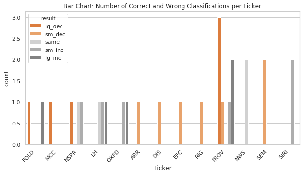

```python
sns.set_style("whitegrid")

# Visualize classifications by Ticker (only observations classified as lg_inc)

colors = {'lg_inc': sns.color_palette("Greys").as_hex()[3],
          'sm_inc': sns.color_palette("Greys").as_hex()[2],
          'same': sns.color_palette("Greys").as_hex()[1],
          'sm_dec': sns.color_palette("Oranges").as_hex()[2],
          'lg_dec': sns.color_palette("Oranges").as_hex()[3]}

df_temp = df_te.groupby("Ticker").size().reset_index().rename(columns = {0: "cnt"})
df_temp = df_temp.loc[df_temp["cnt"] > 10, :]
df_merged = pd.merge(df_te, df_temp, on = "Ticker", how = "right")

df_sub = df_merged
df_sub = df_sub[df_sub["pred"] == "lg_inc"]
df_sub.loc[:, "result"] = df_sub["Y_disc_5"]
df_sub = df_sub.groupby(["result", "Ticker"]).size().reset_index().rename(columns = {0: "count"}).\
        sort_values(["count", "result"])

plt.rcParams["figure.figsize"] = [10,5]
p = sns.barplot(x = "Ticker", y = "count", data = df_sub, hue = "result", palette = colors,
                hue_order = ["lg_dec", "sm_dec", "same", "sm_inc", "lg_inc"])
p.set_xticklabels(p.get_xticklabels(), rotation = 45, horizontalalignment='right')
plt.title("Bar Chart: Number of Correct and Wrong Classifications per Ticker")
plt.show(p)
```